# Chapter 2 analysis (no fringing)

Phase A within years → Phase B temperature does not explain the flips → Phase C what changes with algae

Author

Moorea Chapter 2 notes

Published

September 7, 2026

**Chapter story**

**Phase A — what locates algae in a survey year.**  
Coral (−) and depth (+) hold. Most other predictors still flip after lagoon mix and same-grid checks, so that year-to-year change is real. What drives it is not known yet.

**Phase B — why those relationships flip.**  
Temperature does not explain the flips. No other time-varying covariates, so we cannot ask more than what static covariates can show.

**Phase C — what changes with algae on the same grids.**  
Coral loss tracks algae gain; high-nutrient places amplify that.

### Decision map

Read down the left spine. Side boxes are branches, not the next step. Phase titles sit in the band headers so they cannot cover the first box.

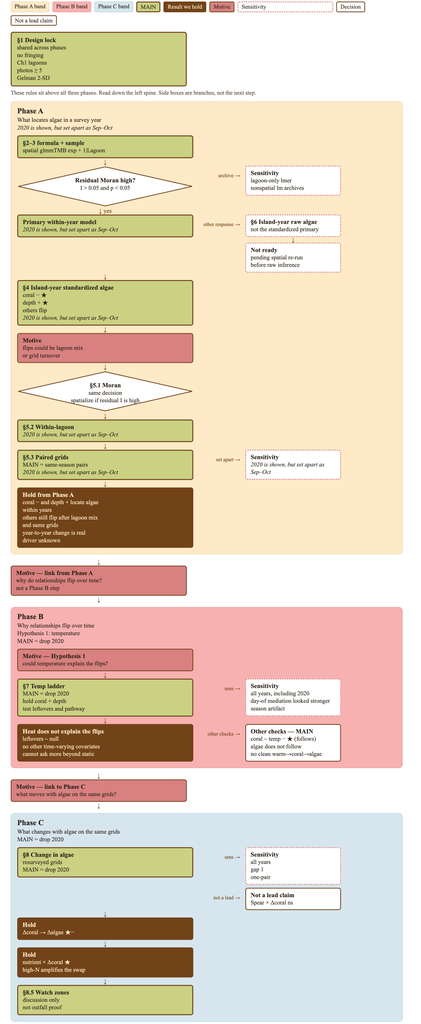

## 1. Design lock

Shared rules for this chapter. Phase A fits each year including **2020** (labeled Sep–Oct). Phase B (§7) and Phase C (§8) drop 2020 when years are pooled.

| Choice | Setting |
| --- | --- |
| Grid | 10 × 10 m |
| Habitat | **Fringing dropped** (Maharepa / Papetoai overrides applied first) |
| Lagoons | **Ch1 fishing filter ON** — drop Tiahura & Papetoai; trim west Pihaena (lon < −149.850) |
| Spear | NA → 0 (`spear_na0`) |
| Nutrient | **Required** — static `nutrient_allYear_percent_n_may` (May %N IDW) |
| Photos | ≥ 5 per grid-year |
| Scaling | Gelman 2-SD on continuous predictors |
| Depth | Bathymetry, negative = below the surface. Positive β = shallower → more algae. |
| Algae metric | `algae_std_A_CHS` = **Algae** / (Algae + Coral + HardSub) — CoralNet **Algae** class (not the separate Macro/Turf columns). Phase C uses the same metric as a change (Δ). |
| Secondary | raw `Algae_mean` — §6 sensitivity; same exp spatial kernel as the standardized primary |
| 2020 | Kept and flagged in Phase A year cells. Dropped when years are pooled (Phase B and Phase C). Pairs that include 2020 = flagged sensitivity (§5.3). |

## Phase A — what locates algae in a survey year

Coral (−) and depth (+) hold. Other predictors still flip after lagoon mix and same-grid checks, so that year-to-year change is real. What drives it is not known yet. 2020 stays, labeled Sep–Oct.

### 2. Model formula — what locates algae

For each year $t$ (**primary**). Sample size for these fits is §3.

$$\begin{aligned}
\texttt{algae\_std\_A\_CHS}_t &\sim \texttt{coral\_std\_A\_CHS}_t + \texttt{herb\_biomass}_t \\
&\quad + \texttt{depth} + \texttt{maxRel} + \texttt{vrm} \\
&\quad + \texttt{offshore\_ratio} + \texttt{min\_dist\_to\_pass} + \texttt{perc\_MPA} \\
&\quad + \texttt{nutrient\_allYear} + \texttt{spearDensity} \\
&\quad + (1 \mid \texttt{Lagoon}) + \texttt{exp}(\texttt{pos3} + 0 \mid \texttt{group})
\end{aligned}$$

- `pos3` = `numFactor(centroidLon, centroidLat)`; one island-wide spatial group.
- Kernel chosen **per year** by AICc among converging exp / Matérn / Gaussian (Gaussian never started; Matérn usually failed Hessian/σ² checks; **exp won all years**).
- Static geography / MPA / **nutrient** / spear do **not** carry a year suffix.
- Herb and coral are **same-year** as the algae response.
- All listed predictors are **required**: `complete.cases` drops any grid missing depth, coral, herb, nutrient, spear, etc.

**Why spatial?** Lagoon-only `lmer` left strong residual Moran I every year (neighbors too similar). Exponential spatial absorbs that map structure so fixed-effect SEs are not anti-conservative. Kernel: **exponential** (`exp`) — AICc winner every year among exp / Matérn / Gaussian (`05r` → `05s`). Lagoon-only `lmer` from `05c` archived as sensitivity (`…/lmer_lagoon_only_sensitivity/`).

**Why lagoon RE still?** Some lagoons have more algae than others for unmeasured lagoon-level reasons; `(1|Lagoon)` absorbs that baseline in addition to fine-scale spatial correlation.

Outputs: `models/10x10/baseline_by_year/`.

**Depth coding (easy to misread)**

`depth_m_mean` is bathymetry in meters where **negative = below the surface** (more negative = **deeper**).  
A **positive** depth coefficient therefore means **shallower grids → more algae** (not “deeper → more algae”).

### 3. Sample size

Complete-case *n* for the §2 formula, by year. **2020*** is kept and labeled (Sep–Oct).

Complete-case sample for primary (std) spatial response

| year | n_grids | n_lagoons | spatial_structure | min_photos | spear_mode | ch1_lagoons | fringing_dropped | season_note |
| --- | --- | --- | --- | --- | --- | --- | --- | --- |
| 2018 | 2964 | 9 | exp_island | 5 | spear_na0 | TRUE | TRUE | May–Jun window |
| 2019 | 1623 | 6 | exp_island | 5 | spear_na0 | TRUE | TRUE | May–Jun window |
| 2020 | 2454 | 7 | exp_island | 5 | spear_na0 | TRUE | TRUE | DIFFERENT SEASON (Sep–Oct) — kept in Phase A; labeled |
| 2021 | 2081 | 5 | exp_island | 5 | spear_na0 | TRUE | TRUE | May–Jun window |
| 2022 | 1250 | 5 | exp_island | 5 | spear_na0 | TRUE | TRUE | May–Jun window |
| 2023 | 3517 | 8 | exp_island | 5 | spear_na0 | TRUE | TRUE | May–Jun window |
| 2024 | 2030 | 7 | exp_island | 5 | spear_na0 | TRUE | TRUE | May–Jun window |

Residual Moran I (kNN=8): lagoon-only null vs primary spatial

| year | spatial | Moran_null | Moran_null_p | Moran_spatial | Moran_spatial_p |
| --- | --- | --- | --- | --- | --- |
| 2022 | exp_island | 0.184 | 5.923e-43 | -0.088 | 1.000000 |
| 2019 | exp_island | 0.164 | 2.159e-43 | -0.090 | 1.000000 |
| 2024 | exp_island | 0.229 | 9.670e-103 | -0.105 | 1.000000 |
| 2021 | exp_island | 0.340 | 2.795e-227 | -0.094 | 1.000000 |
| 2020 | exp_island | 0.451 | < 1e-300 | -0.117 | 1.000000 |
| 2018 | exp_island | 0.381 | < 1e-300 | -0.112 | 1.000000 |
| 2023 | exp_island | 0.226 | 3.209e-169 | -0.090 | 1.000000 |

Lagoon coverage differs by year (field logistics), so **cross-year comparison of coefficients is exploratory**, not a balanced panel.

### 4. Primary results — standardized algae (spatial)

Year cells include **2020*** (red outline). Direction / Significance use **May–Jun only**. The last column of §4.1 (and the scorecard) says whether 2020 matches that May–Jun pattern.

#### 4.1 Estimates, significance & agreement (years shown = all; Dir/Sig = May–Jun)

Gelman-scaled fixed effects (primary). Each year cell shows **estimate** (color = direction) and a **★** when p < 0.05 — **including 2020*** (red outline). **Direction** / **Significance** use **May–Jun years only**. **2020 vs May–Jun** is the alignment check (same information as the old §4.6 table; 2020 estimate and ★ stay in the year cell).

| term | 2018 | 2019 | 2020* | 2021 | 2022 | 2023 | 2024 | Direction | Significance | 2020 vs May–Jun |
| --- | --- | --- | --- | --- | --- | --- | --- | --- | --- | --- |
| Coral (matched scale) | -0.022<sup>★</sup> | -0.039<sup>★</sup> | -0.054<sup>★</sup> | -0.093<sup>★</sup> | -0.050<sup>★</sup> | -0.034<sup>★</sup> | -0.042<sup>★</sup> | ✓ all − | ✓ always ★ | ✓ matches (− ★) |
| Herbivore biomass | -0.010<sup>★</sup> | +0.007 | +0.006 | +0.006 | +0.006 | +0.005 | -0.001 | ✗ flips | ✗ mixed (1/6) | ~ dir matches · ★ differs (+ ns) |
| Depth (bathy; − = deeper) | +0.118<sup>★</sup> | +0.076<sup>★</sup> | +0.124<sup>★</sup> | +0.125<sup>★</sup> | +0.093<sup>★</sup> | +0.068<sup>★</sup> | +0.064<sup>★</sup> | ✓ all + | ✓ always ★ | ✓ matches (+ ★) |
| Max relief | +0.005 | +0.004 | +0.027<sup>★</sup> | +0.021<sup>★</sup> | +0.015 | -0.002 | -0.001 | ✗ flips | ✗ mixed (1/6) | ~ dir matches · ★ differs (+ ★) |
| VRM (rugosity) | +0.006 | +0.005 | +0.029<sup>★</sup> | +0.025<sup>★</sup> | +0.016 | +0.024<sup>★</sup> | +0.010 | ✓ all + | ✗ mixed (2/6) | ~ dir matches · ★ differs (+ ★) |
| Offshore ratio (shore→crest) | +0.025 | -0.073<sup>★</sup> | +0.118<sup>★</sup> | +0.072 | -0.007 | -0.009 | -0.012 | ✗ flips | ✗ mixed (1/6) | ✗ dir differs (+ ★ vs −) |
| Distance to pass | -0.046<sup>★</sup> | -0.010 | +0.064 | -0.045 | +0.127 | +0.020 | -0.006 | ✗ flips | ✗ mixed (1/6) | ✗ dir differs (+ ns vs −) |
| % MPA | +0.025 | +0.016 | -0.059 | -0.023 | -0.043 | -0.025 | +0.024 | ✗ flips | ✓ never ★ | ~ May–Jun mixed · 2020 − ns |
| Nutrient (%N May) | +0.041 | +0.056<sup>★</sup> | +0.039 | +0.011 | +0.188<sup>★</sup> | +0.002 | -0.010 | ✗ flips | ✗ mixed (2/6) | ~ dir matches · ★ differs (+ ns) |
| Spear density | -0.001 | +0.000 | -0.002 | -0.002 | +0.008 | +0.000 | -0.002 | ✗ flips | ✓ never ★ | ✓ matches (− ns) |

blue = +orange = −**★** = p < 0.05Faded cells = not significant. **Direction** / **Significance** = May–Jun only (2020* excluded from those columns). **2020 vs May–Jun** = does the red-outlined year match that pattern (green = dir and ★; amber = dir only or May–Jun already mixed; red = opposite majority). Depth row: bathymetry is reversed (see callout in §2) — positive β = shallower → more algae.

*2020 = different survey season (Sep–Oct); red outline — kept in Phase A year cells.

#### 4.2 Side-by-side table (est + p) — Phase A = all years

Full machine table. Estimate columns include conventional stars: `***` p < 0.001, `**` p < 0.01, `*` p < 0.05, `.` p < 0.1.  
Cells are lightly colored by **sign** (blue +, orange −); significant estimates are bolder. **2020** columns have a red outline (different season — still Phase A).

| term | 2018 est | 2018 p | 2019 est | 2019 p | 2020* est | 2020* p | 2021 est | 2021 p | 2022 est | 2022 p | 2023 est | 2023 p | 2024 est | 2024 p |
| --- | --- | --- | --- | --- | --- | --- | --- | --- | --- | --- | --- | --- | --- | --- |
| Intercept | +0.1357*** | 0.000143 | +0.1064*** | 0.000329 | +0.1721*** | 2.5e-06 | +0.1837*** | 0.000347 | +0.1338*** | 1.81e-08 | +0.0754** | 0.00707 | +0.1074*** | 0.00017 |
| Coral (matched scale) | -0.0225*** | 1.28e-05 | -0.0385*** | 3.81e-15 | -0.0535*** | 2.02e-17 | -0.0929*** | 9.09e-48 | -0.0501*** | 1.21e-12 | -0.0344*** | 4.56e-34 | -0.0425*** | 1.31e-30 |
| Depth (bathy; − = deeper) | +0.1184*** | 1.05e-23 | +0.0757*** | 7.32e-15 | +0.1236*** | 2.95e-27 | +0.1251*** | 1.49e-19 | +0.0926*** | 2.39e-13 | +0.0683*** | 9.37e-31 | +0.0640*** | 5.61e-18 |
| Herbivore biomass | -0.0096* | 0.0305 | +0.0066 | 0.248 | +0.0063 | 0.355 | +0.0063 | 0.298 | +0.0064 | 0.289 | +0.0050. | 0.0823 | -0.0009 | 0.827 |
| Max relief | +0.0048 | 0.507 | +0.0041 | 0.623 | +0.0270*** | 0.00093 | +0.0206* | 0.0166 | +0.0146. | 0.0891 | -0.0019 | 0.683 | -0.0007 | 0.911 |
| Distance to pass | -0.0464* | 0.0321 | -0.0098 | 0.491 | +0.0638 | 0.319 | -0.0450 | 0.614 | +0.1275. | 0.0819 | +0.0196 | 0.137 | -0.0058 | 0.718 |
| Nutrient (%N May) | +0.0406. | 0.0971 | +0.0561** | 0.00236 | +0.0386 | 0.496 | +0.0111 | 0.878 | +0.1884** | 0.00964 | +0.0020 | 0.899 | -0.0102 | 0.591 |
| Offshore ratio (shore→crest) | +0.0252 | 0.11 | -0.0734*** | 0.000441 | +0.1185*** | 2.95e-05 | +0.0724. | 0.0856 | -0.0070 | 0.816 | -0.0095 | 0.379 | -0.0123 | 0.341 |
| % MPA | +0.0253 | 0.356 | +0.0160 | 0.321 | -0.0588 | 0.15 | -0.0233 | 0.78 | -0.0428 | 0.363 | -0.0248 | 0.167 | +0.0237 | 0.442 |
| Spear density | -0.0008 | 0.843 | +0.0003 | 0.949 | -0.0016 | 0.733 | -0.0024 | 0.628 | +0.0076 | 0.105 | +0.0004 | 0.845 | -0.0016 | 0.554 |
| VRM (rugosity) | +0.0065 | 0.434 | +0.0054 | 0.548 | +0.0293** | 0.00103 | +0.0253* | 0.0122 | +0.0158 | 0.13 | +0.0236*** | 7.33e-06 | +0.0097 | 0.142 |

blue = +orange = −Stronger tint + bold = p < 0.05. *2020 red outline = Sep–Oct season (kept in Phase A).

#### 4.3 Hypothesis scorecard — Phase A years shown; Dir/Sig = May–Jun

Island-wide **spatial** std models. **Counts / Dir / Sig / vs hyp** summarize **May–Jun years** (n = 6). The **2020** column flags whether that Sep–Oct year matches the May–Jun pattern (direction and/or ★). Within-lagoon / paired scorecards come later in §5.

| HYPOTHESIS Predictor | HYPOTHESIS Theory | HYPOTHESIS Exp. β | RESULTS — May–Jun (n = 6) Counts (6 May–Jun) | RESULTS — May–Jun (n = 6) Dir | RESULTS — May–Jun (n = 6) Sig | RESULTS — May–Jun (n = 6) vs hyp | RESULTS — May–Jun (n = 6) Takeaway | 2020* vs May–Jun |
| --- | --- | --- | --- | --- | --- | --- | --- | --- |
| Coral (matched scale) | Competition for space More living coral → less hard-substrate space for algae (same-year coral matched to algae). | - | sig **6**/6 +0 / −6 | ✓ all - | ✓ always ★ ★ all match hyp (6) | ✓ matches (always ★) | Strongest support for competition for space — also mathematically expected (shared hard-substrate space: more coral → less room for algae). | ✓ matches − ★ |
| Depth (bathy; − = deeper) | Shallower habitat favors algae (esp. light) Shallower grids favor algae mainly via **more light**; related shallow-water processes (warming, nearshore runoff, access) may contribute but are partly sha… | + | sig **6**/6 +6 / −0 | ✓ all + | ✓ always ★ ★ all match hyp (6) | ✓ matches (always ★) | Shallower habitat favoring algae holds. | ✓ matches + ★ |
| Herbivore biomass | Top-down grazing More herbivore biomass → more grazing → less algae (same-year herb). *Note:* spear and MPA sit on the same causal path (fishing → herbivores → algae), so herb, spear, and MPA can shar… | - | sig **1**/6 +4 / −2 ★ 2018 only | ✗ flips | mixed 1/6 ★ 2018 only ★ matches hyp | ~ lone ★ 2018 matches; most years opposite | Top-down grazing not a stable island-year signal after spatial. | ~ dir matches + ns (May–Jun ★ mixed) |
| Max relief | More structure → algae (relief caveat) maxRel = max−min depth in the grid, so it can reflect **topographic structure** (crevices / surfaces → more algal settlement; expected **+**) *or* a steep **slop… | + | sig **1**/6 +4 / −2 ★ 2021 only | ✗ flips | mixed 1/6 ★ 2021 only ★ matches hyp | ~ lone ★ 2021 matches; dirs mixed | Weak / unstable; structure pathway only weakly supported. | ~ dir matches + ★ (May–Jun ★ mixed) |
| VRM (rugosity) | More complex terrain → algae Higher VRM = more fine-scale **terrain complexity** (not organism density). Expected **+** via more microhabitat / short-dispersal retention and/or reduced grazing access … | + | sig **2**/6 +6 / −0 | ✓ all + | mixed 2/6 ★ all match hyp (2) | ✓ dir matches (★ 2/6) | Supports complexity → algae (herbivore / coral caveats). | ~ dir matches + ★ (May–Jun ★ mixed) |
| Offshore ratio (shore→crest) | Shore→crest position (no signed hyp) Offshore ratio indexes **shore→crest position** (higher = closer to crest). Crestward grids are typically shallower, more wave-exposed, and more continuous reef; s… | ? | sig **1**/6 +2 / −4 ★ 2019 only | ✗ flips | mixed 1/6 ★ 2019 only | no signed hyp | Residual exposure / zoning — context, not a signed driver. | ✗ differs + ★ vs May–Jun - |
| Distance to pass | Closer to pass → more flow → less algae Distance to pass (`min_dist_to_pass_m`): higher = farther from a pass. Near passes: stronger exchange / flushing, often cooler or less stagnant water, and commo… | + | sig **1**/6 +2 / −4 ★ 2018 only | ✗ flips | mixed 1/6 ★ 2018 only ★ opposite hyp | ✗ lone ★ 2018 opposite | Flow / flush story not supported (delivery / habitat caveats). | ✗ differs + ns vs May–Jun - |
| % MPA | Protection → less algae Higher % MPA = more of the grid under protection. Inside / high-MPA: reduced fishing pressure → expected herbivore recovery → less algae. Outside / low-MPA: open to fishing → f… | - | sig **0**/6 +3 / −3 | ✗ flips | never ★ | no ★ years | Residual protection after herb / spear not identifiable. | ~ May–Jun already mixed − ns |
| Nutrient (%N May) | Bottom-up nutrients Higher nutrient supply (static May %N IDW) → more algae (bottom-up). High %N: more enriched water / watershed–nearshore influence as mapped → expected faster algal growth. Low %N: … | + | sig **2**/6 +5 / −1 | ✗ flips | mixed 2/6 ★ all match hyp (2) | ~ all 2 ★ match; dirs mixed but majority matched | Bottom-up direction plausible; limited by static May proxy. | ~ dir matches + ns (May–Jun ★ mixed) |
| Spear density | More fishing → more algae Higher spear density → fewer herbivores → more algae (fishing pathway). High spear: more fishing pressure → expected herbivore depletion → more algae. Low / zero spear: littl… | + | sig **0**/6 +3 / −3 | ✗ flips | never ★ | no ★ years | Not supported as an independent fishing predictor after herb / MPA. | ~ May–Jun already mixed − ns |

*2020 = Sep–Oct season. Green = matches May–Jun pattern; amber = direction matches but ★ pattern differs / May–Jun already mixed; red = direction differs. Same check as the last column of §4.1, next to the hypothesis.

#### 4.4 Coefficient forests (std) by year — Phase A = all years

Below: **one multi-panel forest** with **fixed term order**, **shared x-axis**, and the same significance colors — all Phase A years (2020 included, season labeled in subtitle).

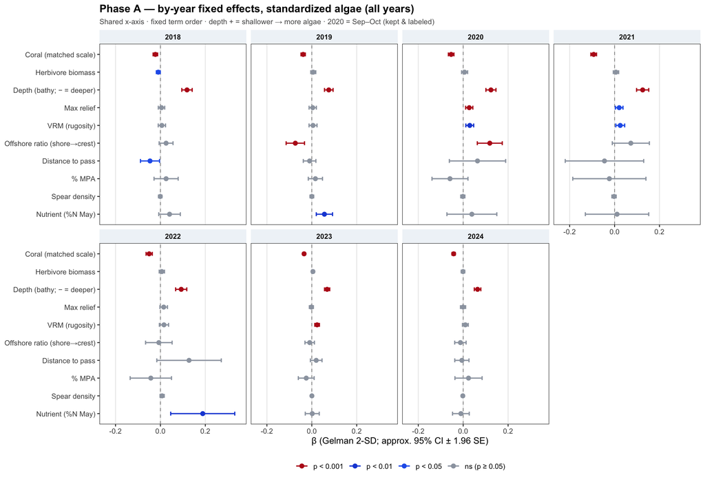

Phase A (all years incl. 2020): comparable forest — standardized algae by year

**Sensitivity — forest May–Jun only (no 2020) + original per-year PNGs**

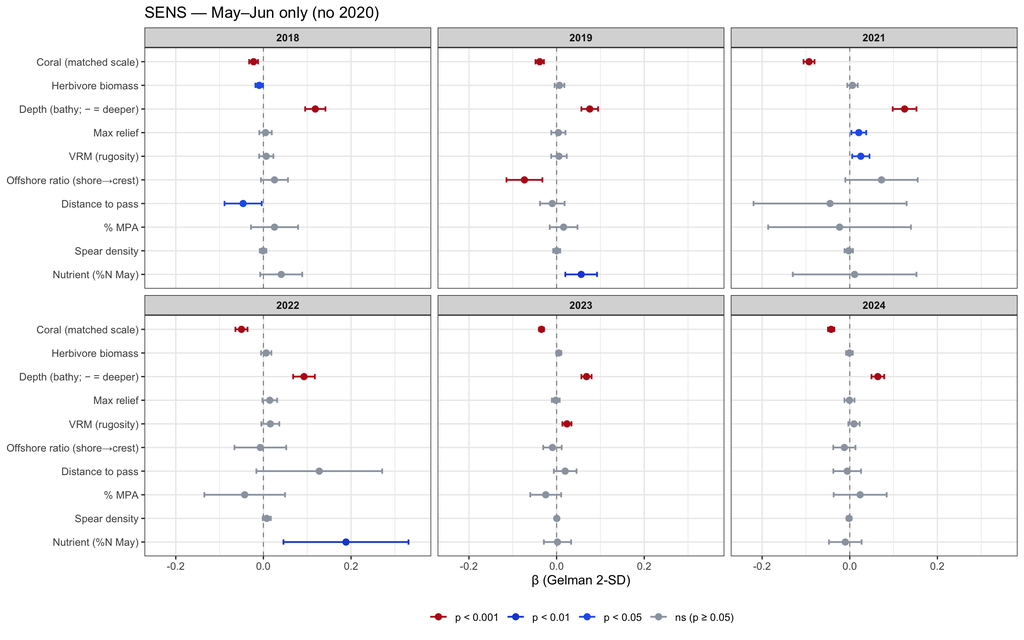

SENS (May–Jun only): comparable forest

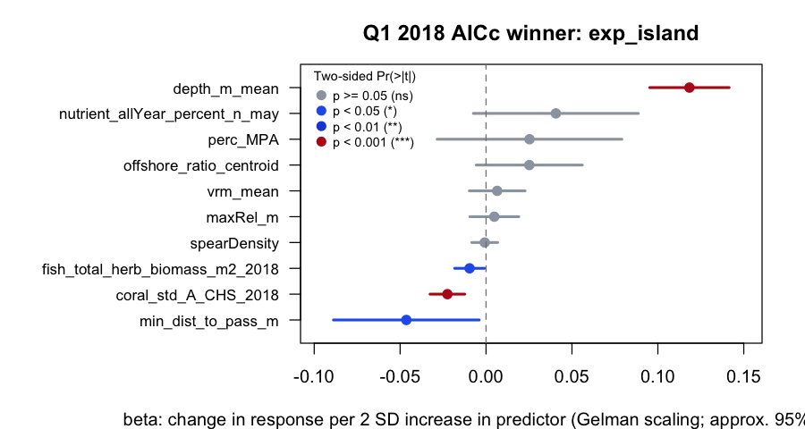

Original per-year forests (not aligned; includes 2020)

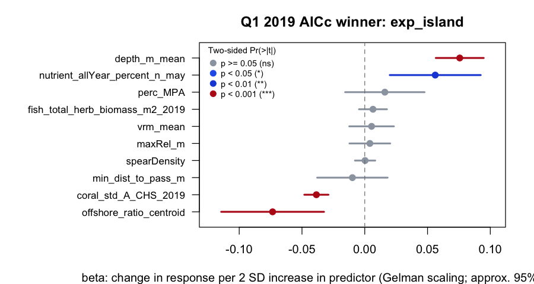

Original per-year forests (not aligned; includes 2020)

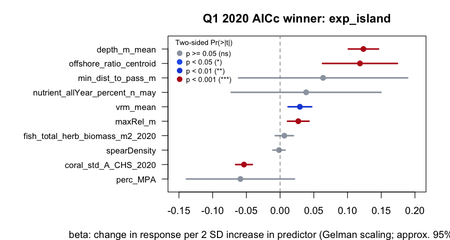

Original per-year forests (not aligned; includes 2020)

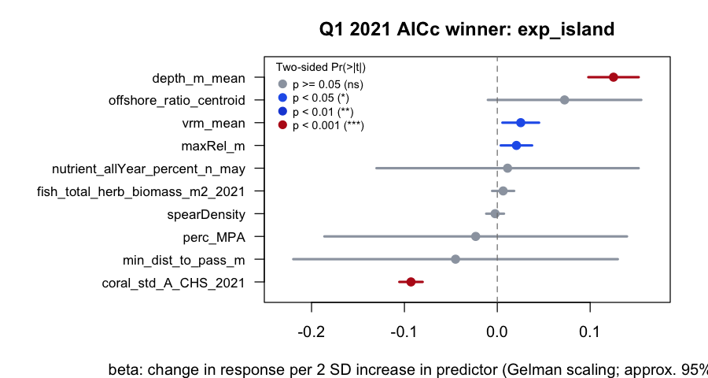

Original per-year forests (not aligned; includes 2020)

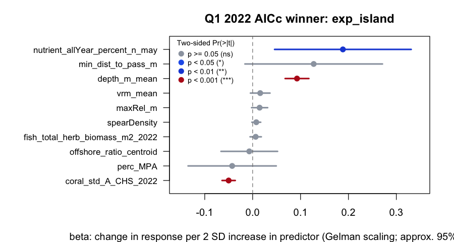

Original per-year forests (not aligned; includes 2020)

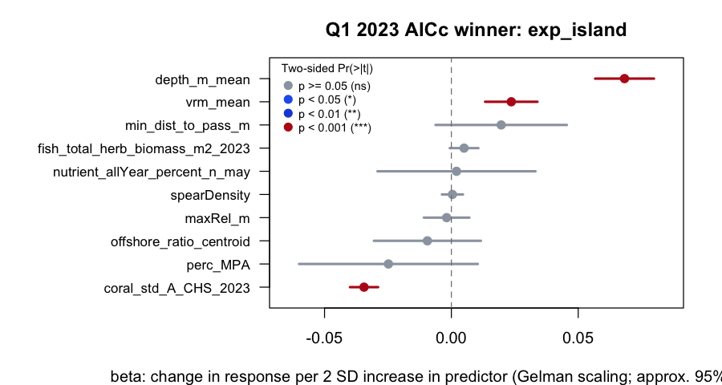

Original per-year forests (not aligned; includes 2020)

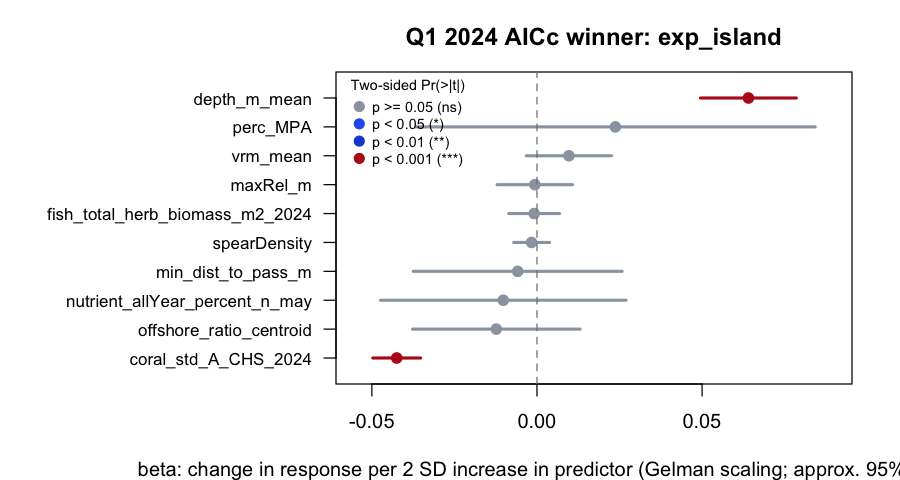

Original per-year forests (not aligned; includes 2020)

#### 4.5 Predictor correlation / collinearity

**Keeps 2020** (Phase A). Pairwise correlations on the **primary sample** (no-fringing inputs, Ch1 fishing lagoons, spear NA→0, photos ≥ 5, complete cases), stacked across **all Phase A years** with that year’s coral/herb. VIF is the same stack (continuous predictors only). Flag |*r*| ≥ 0.5 and VIF ≥ 5; VIF 3–5 = watch. This is a within-year design check (do predictors collinear?), not a cross-year fair pool — so we do **not** drop 2020 here.

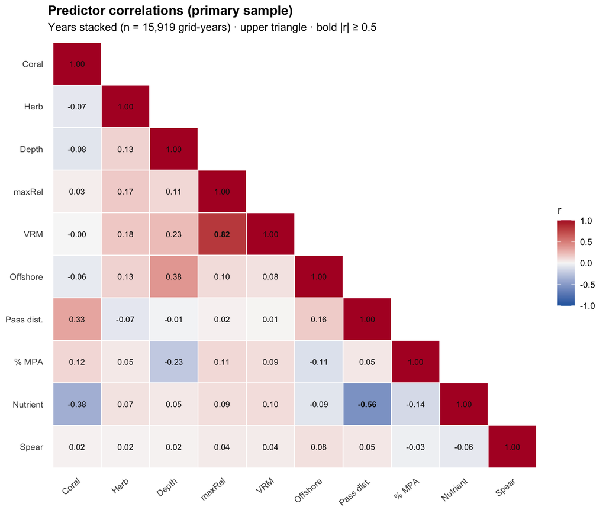

Predictor correlation heatmap (primary sample, years stacked; upper triangle)

**Highest |r| pairs (≥ 0.5):** maxRel · VRM (r = 0.82); Nutrient · Pass dist. (r = -0.56).

VIF (each predictor ~ all other continuous predictors; stacked primary sample, all Phase A years incl. 2020)

|  | term | VIF | flag |
| --- | --- | --- | --- |
| coral | Coral | 1.22 | ok (<3) |
| herb | Herb | 1.07 | ok (<3) |
| depth | Depth | 1.35 | ok (<3) |
| maxRel | maxRel | 3.11 | watch (3–5) |
| vrm | VRM | 3.23 | watch (3–5) |
| offshore | Offshore | 1.27 | ok (<3) |
| pass | Pass dist. | 1.54 | ok (<3) |
| MPA | % MPA | 1.12 | ok (<3) |
| nutrients | Nutrient | 1.62 | ok (<3) |
| spear | Spear | 1.01 | ok (<3) |

### 5. Narrower scope — lagoon, then same grids

Still **Phase A**. Island-wide mixes **which lagoons** appear each year, and within a lagoon the **surveyed cells** turn over. After coral (−) and depth (+) hold under spatial island-year models, we ask: do other predictors stay signed when we stop mixing lagoons, then when we hold the **same cells**?

**2020:** within-lagoon fits **keep 2020 and flag it** (same as §4). **Paired MAIN** uses same-season pairs only; pairs that include 2020 are a flagged sensitivity (one side is Sep–Oct).

Read **§5.1 first** (Moran → spatialize if needed), then the coefficient tables.

| Step | What it is | 2020 |
| --- | --- | --- |
| **5.1 Moran** | Justify spatial refits for the fits below | Applies to both |
| **5.2 Within lagoon × year** | One lagoon held fixed; Dir/★ badges = May–Jun | Kept, flagged |
| **5.3 Paired grids** | Same `grid_ID`s in both years | Pairs that include 2020 = sensitivity |

#### 5.1 Residual Moran — diagnose, then spatialize

Same rule as the island-year models: **before** reading within-lagoon or paired coefficients, check residual autocorrelation. Any narrower fit with Moran I > 0.05 and p < 0.05 was re-fit with spatial correlation. The tables in §5.2–5.3 use those spatial coefficients where the refit succeeded. This section is the justification, not a new result about what locates algae.

**Step A — diagnose `lm` residuals** (`08b`, kNN = 8). Any fit with I > 0.05 & p < 0.05 was queued for spatial refit.

Residual Moran on original lm fits (before spatial)

| analysis | n_fits | mean_I | median_I | pct_I_gt_0.1_and_p_lt_0.05 |
| --- | --- | --- | --- | --- |
| Within lagoon × year (lm) | 47 | 0.122 | 0.108 | 55 |
| Paired year sides (lm) | 96 | -0.001 | -0.009 | 9 |

**Step B — spatial refit** (`05t`/`05u`): `glmmTMB` + `exp(pos3 + 0 | group)` (no lagoon RE). Primary FE tables now use these where successful.

Spatial subset refit summary

| Jobs queued (I>0.05 & p<0.05) | 47 |
| --- | --- |
| Spatial fits succeeded | 42 |
| Mean Moran before → after (successes) | 0.167 → -0.084 |
| Successes still I>0.05 & p<0.05 | 0 |
| Unresolved (stay lm) | 5 |

Successful spatial refits (Moran before → after)

|  | analysis | lagoon | year | year_from | year_to | n_grids | spatial_structure | moran_I_before | moran_I_after | moran_p_after | note |
| --- | --- | --- | --- | --- | --- | --- | --- | --- | --- | --- | --- |
| 44 | paired_year | Haumi | 2021 | 2021 | 2022 | 97 | exp | 0.109 | -0.094 | 0.972 | ok_relaxed_valid |
| 28 | paired_year | Maharepa | 2019 | 2019 | 2022 | 80 | exp | 0.264 | -0.099 | 0.959 | ok |
| 43 | paired_year | Maharepa | 2019 | 2019 | 2021 | 69 | exp | 0.100 | -0.075 | 0.878 | ok_relaxed_valid |
| 27 | paired_year | Maharepa | 2023 | 2020 | 2023 | 69 | exp | 0.104 | -0.071 | 0.861 | ok |
| 34 | paired_year | Maharepa | 2023 | 2023 | 2024 | 215 | exp | 0.061 | -0.063 | 0.968 | ok |
| 31 | paired_year | Pihaena | 2019 | 2019 | 2020 | 111 | exp | 0.123 | -0.088 | 0.967 | ok |
| 32 | paired_year | Pihaena | 2023 | 2021 | 2023 | 126 | exp | 0.084 | -0.033 | 0.728 | ok |
| 41 | paired_year | Pihaena | 2024 | 2020 | 2024 | 59 | exp | 0.103 | -0.105 | 0.937 | ok_relaxed_valid |
| 29 | paired_year | Teavaro | 2022 | 2020 | 2022 | 99 | exp | 0.115 | -0.124 | 0.995 | ok |
| 30 | paired_year | Teavaro | 2023 | 2022 | 2023 | 100 | exp | 0.103 | -0.030 | 0.671 | ok |
| 33 | paired_year | Teavaro | 2023 | 2023 | 2024 | 206 | exp | 0.057 | -0.046 | 0.903 | ok |
| 26 | paired_year | Tiaia | 2024 | 2021 | 2024 | 67 | exp | 0.159 | -0.073 | 0.859 | ok |
| 36 | within_lagoon | Haumi | 2018 | NA | NA | 157 | exp | 0.225 | -0.092 | 0.989 | ok_relaxed_valid |
| 2 | within_lagoon | Haumi | 2019 | NA | NA | 147 | exp | 0.115 | -0.088 | 0.983 | ok |
| 13 | within_lagoon | Haumi | 2020 | NA | NA | 380 | exp | 0.206 | -0.098 | 1.000 | ok |
| 3 | within_lagoon | Haumi | 2021 | NA | NA | 198 | exp | 0.148 | -0.088 | 0.994 | ok |
| 39 | within_lagoon | Haumi | 2023 | NA | NA | 263 | exp | 0.075 | -0.071 | 0.989 | ok_relaxed_valid |
| 11 | within_lagoon | Maatea | 2018 | NA | NA | 342 | exp | 0.386 | -0.113 | 1.000 | ok |
| 18 | within_lagoon | Maharepa | 2018 | NA | NA | 511 | exp | 0.261 | -0.107 | 1.000 | ok |
| 4 | within_lagoon | Maharepa | 2019 | NA | NA | 205 | exp | 0.182 | -0.088 | 0.995 | ok |
| 17 | within_lagoon | Maharepa | 2020 | NA | NA | 508 | exp | 0.256 | -0.117 | 1.000 | ok |
| 22 | within_lagoon | Maharepa | 2021 | NA | NA | 750 | exp | 0.294 | -0.091 | 1.000 | ok |
| 25 | within_lagoon | Maharepa | 2023 | NA | NA | 875 | exp | 0.128 | -0.058 | 1.000 | ok |
| 21 | within_lagoon | Maharepa | 2024 | NA | NA | 549 | exp | 0.225 | -0.088 | 1.000 | ok |
| 38 | within_lagoon | Patae | 2018 | NA | NA | 239 | exp | 0.069 | -0.049 | 0.928 | ok_relaxed_valid |
| 19 | within_lagoon | Pihaena | 2018 | NA | NA | 522 | exp | 0.182 | -0.094 | 1.000 | ok |
| 24 | within_lagoon | Pihaena | 2020 | NA | NA | 813 | exp | 0.357 | -0.105 | 1.000 | ok |
| 6 | within_lagoon | Pihaena | 2022 | NA | NA | 304 | exp | 0.066 | -0.035 | 0.880 | ok |
| 16 | within_lagoon | Pihaena | 2023 | NA | NA | 460 | exp | 0.113 | -0.089 | 1.000 | ok |
| 5 | within_lagoon | Pihaena | 2024 | NA | NA | 281 | exp | 0.230 | -0.114 | 1.000 | ok |
| 12 | within_lagoon | Teavaro | 2018 | NA | NA | 377 | exp | 0.320 | -0.101 | 1.000 | ok |
| 7 | within_lagoon | Teavaro | 2020 | NA | NA | 321 | exp | 0.129 | -0.044 | 0.945 | ok |
| 14 | within_lagoon | Teavaro | 2022 | NA | NA | 385 | exp | 0.127 | -0.051 | 0.978 | ok |
| 23 | within_lagoon | Teavaro | 2023 | NA | NA | 798 | exp | 0.108 | -0.106 | 1.000 | ok |
| 15 | within_lagoon | Teavaro | 2024 | NA | NA | 405 | exp | 0.067 | -0.085 | 1.000 | ok |
| 20 | within_lagoon | Tiaia | 2021 | NA | NA | 528 | exp | 0.271 | -0.081 | 1.000 | ok |
| 9 | within_lagoon | Tiaia | 2023 | NA | NA | 326 | exp | 0.125 | -0.082 | 0.999 | ok |
| 8 | within_lagoon | Tiaia | 2024 | NA | NA | 324 | exp | 0.103 | -0.090 | 0.999 | ok |
| 35 | within_lagoon | Vaianae | 2020 | NA | NA | 151 | exp | 0.174 | -0.129 | 0.999 | ok_relaxed_valid |
| 40 | within_lagoon | Vaianae | 2023 | NA | NA | 278 | exp | 0.101 | -0.068 | 0.991 | ok_relaxed_valid |
| 10 | within_lagoon | Varari | 2018 | NA | NA | 334 | exp | 0.234 | -0.070 | 0.995 | ok |
| 1 | within_lagoon | Varari | 2020 | NA | NA | 146 | exp | 0.343 | -0.122 | 0.999 | ok |

Unresolved — remain lm (spatial did not improve Moran)

|  | analysis | lagoon | year | year_from | year_to | n_grids | moran_I_before | note |
| --- | --- | --- | --- | --- | --- | --- | --- | --- |
| 37 | within_lagoon | Haumi | 2022 | NA | NA | 203 | 0.082 | no_moran_improvement |
| 42 | paired_year | Teavaro | 2020 | 2019 | 2020 | 64 | 0.090 | no_moran_improvement |
| 45 | paired_year | Pihaena | 2024 | 2023 | 2024 | 101 | 0.068 | no_moran_improvement |
| 46 | paired_year | Pihaena | 2020 | 2020 | 2023 | 120 | 0.061 | no_moran_improvement |
| 47 | paired_year | Maharepa | 2024 | 2023 | 2024 | 215 | 0.091 | no_moran_improvement |

**Status**

**42 / 47** high-Moran subset fits are now spatial with residual Moran near zero or negative. The five unresolved cases had only mild lm Moran (I ≈ 0.06–0.09); they stay `lm` and are flagged above.

#### 5.2 Within lagoon × year

Fits the primary formula **separately in each lagoon–year** (so year-to-year differences are not driven by swapping lagoons in/out of the island mix). High-Moran years are **spatial** (§5.1). Dir/★ badges exclude 2020.

**Sample size by lagoon × year** (complete-case grids). Darker = more grids. Fits require n ≥ 50. 2020* = Sep–Oct (kept in Phase A).

|  | 2018 | 2019 | 2020* | 2021 | 2022 | 2023 | 2024 | # yr fitted |
| --- | --- | --- | --- | --- | --- | --- | --- | --- |
| Maharepa | 511 | 205 | 508 | 750 | 241 | 875 | 549 | 7 |
| Pihaena | 522 | 243 | 813 | 282 | 304 | 460 | 281 | 7 |
| Teavaro | 377 | 269 | 321 | 323 | 385 | 798 | 405 | 7 |
| Tiaia | 116 | 117 | 135 | 528 | 117 | 326 | 324 | 7 |
| Haumi | 157 | 147 | 380 | 198 | 203 | 263 | — | 6 |
| Vaianae | 366 | — | 151 | — | — | 278 | 93 | 4 |
| Varari | 334 | — | 146 | — | — | 167 | 204 | 4 |
| Patae | 239 | — | — | — | — | 350 | 174 | 3 |
| Maatea | 342 | 642 | — | — | — | — | — | 2 |

**Model type by lagoon × year** (std primary): `S` = spatial exp · `L` = lm (Moran did not require / could not improve spatial). 2020* = Sep–Oct (kept, flagged).

|  | 2018 | 2019 | 2020* | 2021 | 2022 | 2023 | 2024 |
| --- | --- | --- | --- | --- | --- | --- | --- |
| Maharepa | S | S | S | S | L | S | S |
| Pihaena | S | L | S | L | S | S | S |
| Teavaro | S | L | S | L | S | S | S |
| Tiaia | L | L | L | S | L | S | S |
| Haumi | S | S | S | S | L | S | — |
| Vaianae | L | — | S | — | — | S | L |
| Varari | S | — | S | — | — | L | L |
| Patae | S | — | — | — | — | L | L |
| Maatea | S | L | — | — | — | — | — |

**Stability of key predictors within each lagoon** (all lagoons with ≥1 fitted year; spatial-updated). Header = lagoon (**n** years fitted).  
**Dir / ★ badges = May–Jun years only** (same rule as §4.1); 2020 fits still appear in the coverage table above.

| term | Maharepa (7) | Pihaena (7) | Teavaro (7) | Tiaia (7) | Haumi (6) | Vaianae (4) | Varari (4) | Patae (3) | Maatea (2) | Takeaway |
| --- | --- | --- | --- | --- | --- | --- | --- | --- | --- | --- |
| Coral (matched scale) | − ★ 5/6 same dir / mixed ★ | − ★ 6/6 same dir / same ★ | − ★ 3/6 same dir / mixed ★ | 1+ / 5− ★ 5/6 dir flips / mixed ★ | 2+ / 3− ★ 0/5 dir flips / same ★ | 1+ / 2− ★ 0/3 dir flips / same ★ | 2+ / 1− ★ 1/3 dir flips / mixed ★ | 2+ / 1− ★ 0/3 dir flips / same ★ | 1+ / 1− ★ 0/2 dir flips / same ★ | Holds in best-sampled lagoons (Pihaena, Maharepa, Teavaro); flips or weak elsewhere — not only lagoon mixing. |
| Depth (bathy; − = deeper) | + ★ 5/6 same dir / mixed ★ | + ★ 5/6 same dir / mixed ★ | + ★ 5/6 same dir / mixed ★ | + ★ 6/6 same dir / same ★ | + ★ 5/5 same dir / same ★ | + ★ 3/3 same dir / same ★ | 2+ / 1− ★ 1/3 dir flips / mixed ★ | 2+ / 1− ★ 0/3 dir flips / same ★ | + ★ 2/2 same dir / same ★ | Clearest within-lagoon win: almost every lagoon all + (often ★). Survives holding lagoon fixed. |
| Herbivore biomass | 4+ / 2− ★ 1/6 dir flips / mixed ★ | 4+ / 2− ★ 1/6 dir flips / mixed ★ | 2+ / 4− ★ 0/6 dir flips / same ★ | 2+ / 4− ★ 1/6 dir flips / mixed ★ | 3+ / 2− ★ 1/5 dir flips / mixed ★ | 1+ / 2− ★ 2/3 dir flips / mixed ★ | 2+ / 1− ★ 0/3 dir flips / same ★ | 2+ / 1− ★ 1/3 dir flips / mixed ★ | 1+ / 1− ★ 0/2 dir flips / same ★ | Flips in every lagoon; few ★. No stable grazing signal within lagoons either. |
| Max relief | 5+ / 1− ★ 0/6 dir flips / same ★ | 4+ / 2− ★ 0/6 dir flips / same ★ | 2+ / 4− ★ 1/6 dir flips / mixed ★ | 4+ / 2− ★ 0/6 dir flips / same ★ | 3+ / 2− ★ 0/5 dir flips / same ★ | 2+ / 1− ★ 1/3 dir flips / mixed ★ | − ★ 0/3 same dir / same ★ | + ★ 1/3 same dir / mixed ★ | 1+ / 1− ★ 0/2 dir flips / same ★ | Mostly flips; almost never ★. Structure-via-relief weak once inside a lagoon. |
| VRM (rugosity) | 5+ / 1− ★ 1/6 dir flips / mixed ★ | 5+ / 1− ★ 2/6 dir flips / mixed ★ | + ★ 3/6 same dir / mixed ★ | 4+ / 2− ★ 0/6 dir flips / same ★ | + ★ 3/5 same dir / mixed ★ | 2+ / 1− ★ 2/3 dir flips / mixed ★ | + ★ 0/3 same dir / same ★ | 1+ / 2− ★ 0/3 dir flips / same ★ | + ★ 0/2 same dir / same ★ | Better than maxRel (several lagoons all +) but ★ only sometimes; not a clean always-★ driver. |
| Offshore ratio (shore→crest) | 4+ / 2− ★ 2/6 dir flips / mixed ★ | 4+ / 2− ★ 4/6 dir flips / mixed ★ | 5+ / 1− ★ 0/6 dir flips / same ★ | 4+ / 2− ★ 1/6 dir flips / mixed ★ | 1+ / 4− ★ 2/5 dir flips / mixed ★ | 1+ / 2− ★ 0/3 dir flips / same ★ | 1+ / 2− ★ 1/3 dir flips / mixed ★ | + ★ 1/3 same dir / mixed ★ | − ★ 1/2 same dir / mixed ★ | Flips almost everywhere; no shared sign. Fits context / no signed hyp. |
| Distance to pass | 5+ / 1− ★ 2/6 dir flips / mixed ★ | 3+ / 3− ★ 2/6 dir flips / mixed ★ | 3+ / 3− ★ 3/6 dir flips / mixed ★ | 2+ / 4− ★ 1/6 dir flips / mixed ★ | 2+ / 3− ★ 1/5 dir flips / mixed ★ | 1+ / 2− ★ 0/3 dir flips / same ★ | 1+ / 2− ★ 1/3 dir flips / mixed ★ | 1+ / 2− ★ 1/3 dir flips / mixed ★ | − ★ 2/2 same dir / same ★ | Flips in nearly every lagoon; Maatea stably opposite the flush hyp. Flow story does not hold within lagoons. |
| % MPA | 4+ / 1− ★ 1/5 dir flips / mixed ★ | − ★ 0/1 same dir / same ★ | − ★ 2/3 same dir / mixed ★ | — | — | — | — | − ★ 0/1 same dir / same ★ | + ★ 0/1 same dir / same ★ | Sparse MPA variation; weak / mixed where present. Still hard to identify after herb/spear. |
| Nutrient (%N May) | 5+ / 1− ★ 1/6 dir flips / mixed ★ | 2+ / 4− ★ 2/6 dir flips / mixed ★ | − ★ 1/6 same dir / mixed ★ | 3+ / 3− ★ 1/6 dir flips / mixed ★ | 2+ / 3− ★ 0/5 dir flips / same ★ | 1+ / 2− ★ 0/3 dir flips / same ★ | 1+ / 2− ★ 0/3 dir flips / same ★ | 1+ / 2− ★ 2/3 dir flips / mixed ★ | + ★ 0/2 same dir / same ★ | Flips almost everywhere (~half + / half −). Static May proxy no clearer inside lagoons. |
| Spear density | 3+ / 3− ★ 0/6 dir flips / same ★ | 3+ / 3− ★ 0/6 dir flips / same ★ | 2+ / 4− ★ 0/6 dir flips / same ★ | 3+ / 3− ★ 2/6 dir flips / mixed ★ | + ★ 1/5 same dir / mixed ★ | 2+ / 1− ★ 0/3 dir flips / same ★ | − ★ 0/3 same dir / same ★ | 2+ / 1− ★ 0/3 dir flips / same ★ | − ★ 0/2 same dir / same ★ | Flips in most lagoons; almost never ★. No independent fishing signal within lagoons. |

Cell top line = direction summary and ★ count among **May–Jun** fitted years in that lagoon (2020 excluded from these badges; still in coverage). same dir / same ★ same dir / mixed ★ dir flips / same ★ dir flips / mixed ★

**Full within-lagoon side-by-side (all lagoons stacked)**

Std within-lagoon side-by-side (all lagoons with ≥3 fitted years)

| lagoon | term | y2018_est | y2018_p | y2018_model | y2019_est | y2019_p | y2019_model | y2020_est | y2020_p | y2020_model | y2021_est | y2021_p | y2021_model | y2022_est | y2022_p | y2022_model | y2023_est | y2023_p | y2023_model | y2024_est | y2024_p | y2024_model | sig_pattern | sign_pattern | n_years | n_years_sig |
| --- | --- | --- | --- | --- | --- | --- | --- | --- | --- | --- | --- | --- | --- | --- | --- | --- | --- | --- | --- | --- | --- | --- | --- | --- | --- | --- |
| Haumi | Intercept | 0.1680 | 0.0000000 | exp | 0.0526 | 0.0000000 | exp | 0.0592 | 0.0000000 | exp | 0.0393 | 0.0080729 | exp | 0.0525 | 0.0000000 | lm | 0.0380 | 0.0000000 | exp | NA | NA | NA | same | same | 6 | 6 |
| Haumi | Coral (matched scale) | 0.0267 | 0.2120886 | exp | -0.0071 | 0.5162594 | exp | -0.0224 | 0.0026169 | exp | -0.0078 | 0.2976812 | exp | -0.0180 | 0.0514703 | lm | 0.0048 | 0.4746503 | exp | NA | NA | NA | mixed | diff | 6 | 1 |
| Haumi | Depth (bathy; − = deeper) | 0.0584 | 0.0405975 | exp | 0.0388 | 0.0228140 | exp | 0.0610 | 0.0000043 | exp | 0.0376 | 0.0271981 | exp | 0.0558 | 0.0010912 | lm | 0.0343 | 0.0000048 | exp | NA | NA | NA | same | same | 6 | 6 |
| Haumi | Herbivore biomass | -0.0169 | 0.4808840 | exp | 0.0069 | 0.5282677 | exp | 0.0120 | 0.2980259 | exp | 0.0029 | 0.7536061 | exp | -0.0098 | 0.2380746 | lm | 0.0240 | 0.0005004 | exp | NA | NA | NA | mixed | diff | 6 | 1 |
| Haumi | Max relief | 0.0012 | 0.9710207 | exp | -0.0017 | 0.9081204 | exp | 0.0167 | 0.1546264 | exp | 0.0233 | 0.0633183 | exp | 0.0035 | 0.7514245 | lm | -0.0054 | 0.5747715 | exp | NA | NA | NA | same | diff | 6 | 0 |
| Haumi | Distance to pass | -0.0302 | 0.4611489 | exp | 0.0360 | 0.3473832 | exp | 0.0321 | 0.1148710 | exp | -0.0270 | 0.6732329 | exp | 0.0766 | 0.0134439 | lm | -0.0270 | 0.3859176 | exp | NA | NA | NA | mixed | diff | 6 | 1 |
| Haumi | Nutrient (%N May) | -0.0279 | 0.4984999 | exp | -0.0085 | 0.8020303 | exp | 0.0356 | 0.0702463 | exp | 0.0286 | 0.6079410 | exp | -0.0149 | 0.5898397 | lm | 0.0334 | 0.1361181 | exp | NA | NA | NA | same | diff | 6 | 0 |
| Haumi | Offshore ratio (shore→crest) | 0.0521 | 0.2090352 | exp | -0.0586 | 0.0048080 | exp | -0.0439 | 0.0068935 | exp | -0.0321 | 0.2394352 | exp | -0.0952 | 0.0000000 | lm | -0.0163 | 0.3860803 | exp | NA | NA | NA | mixed | diff | 6 | 3 |
| Haumi | Spear density | 0.0108 | 0.5821042 | exp | 0.0040 | 0.6503498 | exp | 0.0079 | 0.2371756 | exp | 0.0132 | 0.0346514 | exp | 0.0048 | 0.5241111 | lm | 0.0008 | 0.8890047 | exp | NA | NA | NA | mixed | same | 6 | 1 |
| Haumi | VRM (rugosity) | 0.0248 | 0.4074041 | exp | 0.0275 | 0.0209740 | exp | 0.0051 | 0.6752183 | exp | 0.0237 | 0.0357033 | exp | 0.0367 | 0.0032008 | lm | 0.0182 | 0.1000771 | exp | NA | NA | NA | mixed | same | 6 | 3 |
| Maharepa | Intercept | 0.1784 | 0.0000000 | exp | 0.2060 | 0.0000000 | exp | 0.1671 | 0.0000000 | exp | 0.2818 | 0.0001791 | exp | 0.1328 | 0.0000000 | lm | 0.1232 | 0.0000000 | exp | 0.1596 | 0.0000000 | exp | same | same | 7 | 7 |
| Maharepa | Coral (matched scale) | -0.0178 | 0.1034312 | exp | -0.0495 | 0.0095719 | exp | -0.0454 | 0.0006034 | exp | -0.1447 | 0.0000000 | exp | -0.0578 | 0.0000012 | lm | -0.0640 | 0.0000000 | exp | -0.0599 | 0.0000000 | exp | mixed | same | 7 | 6 |
| Maharepa | Depth (bathy; − = deeper) | 0.2308 | 0.0000000 | exp | 0.0422 | 0.4857780 | exp | 0.2404 | 0.0000000 | exp | 0.3119 | 0.0000000 | exp | 0.1285 | 0.0000038 | lm | 0.0905 | 0.0000000 | exp | 0.0885 | 0.0000000 | exp | mixed | same | 7 | 6 |
| Maharepa | Herbivore biomass | -0.0169 | 0.2359558 | exp | 0.0305 | 0.1538553 | exp | 0.0018 | 0.9053591 | exp | -0.0071 | 0.5111724 | exp | 0.0348 | 0.0025727 | lm | 0.0146 | 0.0540421 | exp | 0.0035 | 0.6506864 | exp | mixed | diff | 7 | 1 |
| Maharepa | Max relief | 0.0074 | 0.6776116 | exp | -0.0215 | 0.4734319 | exp | -0.0024 | 0.9038359 | exp | 0.0237 | 0.1375289 | exp | 0.0147 | 0.3995692 | lm | 0.0001 | 0.9912743 | exp | 0.0007 | 0.9490943 | exp | same | diff | 7 | 0 |
| Maharepa | Distance to pass | 0.0386 | 0.2226318 | exp | 0.2180 | 0.2138178 | exp | 0.0417 | 0.3424522 | exp | -0.0099 | 0.9280247 | exp | 0.3111 | 0.0000076 | lm | 0.0335 | 0.0371267 | exp | 0.0065 | 0.6990476 | exp | mixed | diff | 7 | 2 |
| Maharepa | Nutrient (%N May) | 0.0464 | 0.2452370 | exp | 0.2361 | 0.0977077 | exp | 0.0130 | 0.7370354 | exp | -0.1000 | 0.1249463 | exp | 0.2370 | 0.0000169 | lm | 0.0220 | 0.2453162 | exp | 0.0304 | 0.2134320 | exp | mixed | diff | 7 | 1 |
| Maharepa | Offshore ratio (shore→crest) | 0.0400 | 0.2323551 | exp | 0.1133 | 0.1122816 | exp | 0.0043 | 0.9243593 | exp | 0.1644 | 0.0598469 | exp | 0.0945 | 0.0010319 | lm | -0.0292 | 0.0690376 | exp | -0.0507 | 0.0307777 | exp | mixed | diff | 7 | 2 |
| Maharepa | % MPA | 0.0187 | 0.0677518 | exp | 0.0150 | 0.3680283 | exp | 0.0227 | 0.0582181 | exp | -0.0111 | 0.2001841 | exp | 0.0281 | 0.0078274 | lm | NA | NA | exp | 0.0027 | 0.6258734 | exp | mixed | diff | 6 | 1 |
| Maharepa | Spear density | 0.0104 | 0.3437354 | exp | -0.0013 | 0.9455132 | exp | -0.0202 | 0.0712580 | exp | -0.0154 | 0.0935760 | exp | 0.0158 | 0.1347599 | lm | 0.0009 | 0.8750138 | exp | -0.0093 | 0.1464282 | exp | same | diff | 7 | 0 |
| Maharepa | VRM (rugosity) | -0.0171 | 0.4704869 | exp | 0.0648 | 0.0517995 | exp | 0.0350 | 0.0998757 | exp | 0.0634 | 0.0002073 | exp | 0.0108 | 0.5893246 | lm | 0.0206 | 0.0910212 | exp | 0.0083 | 0.5175178 | exp | mixed | diff | 7 | 1 |
| Patae | Intercept | 0.0553 | 0.0000000 | exp | NA | NA | NA | NA | NA | NA | NA | NA | NA | NA | NA | NA | 0.0233 | 0.0000000 | lm | 0.0201 | 0.0000000 | lm | same | same | 3 | 3 |
| Patae | Coral (matched scale) | -0.0062 | 0.4696155 | exp | NA | NA | NA | NA | NA | NA | NA | NA | NA | NA | NA | NA | 0.0005 | 0.9173964 | lm | 0.0038 | 0.3761615 | lm | same | diff | 3 | 0 |
| Patae | Depth (bathy; − = deeper) | 0.0128 | 0.3632651 | exp | NA | NA | NA | NA | NA | NA | NA | NA | NA | NA | NA | NA | 0.0114 | 0.0645076 | lm | -0.0025 | 0.7270854 | lm | same | diff | 3 | 0 |
| Patae | Herbivore biomass | -0.0060 | 0.5134111 | exp | NA | NA | NA | NA | NA | NA | NA | NA | NA | NA | NA | NA | 0.0003 | 0.9522996 | lm | 0.0140 | 0.0088122 | lm | mixed | diff | 3 | 1 |
| Patae | Max relief | 0.0323 | 0.0079589 | exp | NA | NA | NA | NA | NA | NA | NA | NA | NA | NA | NA | NA | 0.0067 | 0.4641563 | lm | 0.0122 | 0.0918735 | lm | mixed | same | 3 | 1 |
| Patae | Distance to pass | -0.1326 | 0.0000000 | exp | NA | NA | NA | NA | NA | NA | NA | NA | NA | NA | NA | NA | -0.0029 | 0.9225568 | lm | 0.0066 | 0.3118073 | lm | mixed | diff | 3 | 1 |
| Patae | Nutrient (%N May) | 0.0870 | 0.0000000 | exp | NA | NA | NA | NA | NA | NA | NA | NA | NA | NA | NA | NA | -0.0203 | 0.0834119 | lm | -0.0174 | 0.0328041 | lm | mixed | diff | 3 | 2 |
| Patae | Offshore ratio (shore→crest) | 0.0323 | 0.0657775 | exp | NA | NA | NA | NA | NA | NA | NA | NA | NA | NA | NA | NA | 0.0062 | 0.7762129 | lm | 0.0203 | 0.0197839 | lm | mixed | same | 3 | 1 |
| Patae | % MPA | NA | NA | exp | NA | NA | NA | NA | NA | NA | NA | NA | NA | NA | NA | NA | -0.0136 | 0.5315639 | lm | NA | NA | lm | n/a | n/a | 1 | 0 |

[output cut: 54 more lines]

#### 5.3 Paired grids (same cells, two years)

**What this is:** same formula, but only on grids surveyed (and complete-case) in **both** years of a pair (overlap n ≥ 50). Strictest check that year-to-year flips aren’t just surveying different parts of the lagoon.

**MAIN = same-season pairs** (neither year is 2020). A pair that includes 2020 compares May–Jun with Sep–Oct, so those pairs are a **flagged sensitivity**, not the readout for “flips persist on the same grids.”

**MAIN:** **34** same-season lagoon×year-pairs (across **7** lagoons). **Sensitivity:** **14** pairs include 2020 (season mismatch) — listed below, not in the MAIN stability table.

**Which pairs fitted — MAIN (same season) and sensitivity (includes 2020)**

Fitted paired overlaps (MAIN = no 2020; SENS = includes 2020)

| Role | Lagoon | Year A | Year B | n overlap |
| --- | --- | --- | --- | --- |
| MAIN | Haumi | 2019 | 2021 | 54 |
| MAIN | Haumi | 2019 | 2022 | 66 |
| MAIN | Haumi | 2021 | 2022 | 97 |
| MAIN | Maharepa | 2019 | 2021 | 69 |
| MAIN | Maharepa | 2019 | 2022 | 80 |
| MAIN | Maharepa | 2021 | 2022 | 74 |
| MAIN | Maharepa | 2021 | 2024 | 60 |
| MAIN | Maharepa | 2022 | 2024 | 61 |
| MAIN | Maharepa | 2023 | 2024 | 215 |
| MAIN | Patae | 2023 | 2024 | 60 |
| MAIN | Pihaena | 2019 | 2021 | 80 |
| MAIN | Pihaena | 2019 | 2022 | 134 |
| MAIN | Pihaena | 2019 | 2023 | 113 |
| MAIN | Pihaena | 2019 | 2024 | 84 |
| MAIN | Pihaena | 2021 | 2022 | 103 |
| MAIN | Pihaena | 2021 | 2023 | 126 |
| MAIN | Pihaena | 2021 | 2024 | 51 |
| MAIN | Pihaena | 2022 | 2023 | 134 |
| MAIN | Pihaena | 2022 | 2024 | 64 |
| MAIN | Pihaena | 2023 | 2024 | 101 |
| MAIN | Teavaro | 2018 | 2021 | 51 |
| MAIN | Teavaro | 2019 | 2021 | 106 |
| MAIN | Teavaro | 2019 | 2022 | 104 |
| MAIN | Teavaro | 2019 | 2023 | 58 |
| MAIN | Teavaro | 2021 | 2022 | 100 |
| MAIN | Teavaro | 2021 | 2023 | 57 |
| MAIN | Teavaro | 2022 | 2023 | 100 |
| MAIN | Teavaro | 2023 | 2024 | 206 |
| MAIN | Tiaia | 2019 | 2021 | 51 |
| MAIN | Tiaia | 2021 | 2022 | 64 |
| MAIN | Tiaia | 2021 | 2023 | 76 |
| MAIN | Tiaia | 2021 | 2024 | 67 |
| MAIN | Tiaia | 2023 | 2024 | 115 |
| MAIN | Varari | 2023 | 2024 | 62 |
| SENS (includes 2020) | Haumi | 2020 | 2021 | 90 |
| SENS (includes 2020) | Haumi | 2020 | 2022 | 112 |
| SENS (includes 2020) | Maharepa | 2020 | 2021 | 94 |
| SENS (includes 2020) | Maharepa | 2020 | 2022 | 96 |
| SENS (includes 2020) | Maharepa | 2020 | 2023 | 69 |
| SENS (includes 2020) | Pihaena | 2018 | 2020 | 64 |
| SENS (includes 2020) | Pihaena | 2019 | 2020 | 111 |
| SENS (includes 2020) | Pihaena | 2020 | 2021 | 73 |
| SENS (includes 2020) | Pihaena | 2020 | 2022 | 118 |
| SENS (includes 2020) | Pihaena | 2020 | 2023 | 120 |
| SENS (includes 2020) | Pihaena | 2020 | 2024 | 59 |
| SENS (includes 2020) | Teavaro | 2019 | 2020 | 64 |
| SENS (includes 2020) | Teavaro | 2020 | 2021 | 87 |
| SENS (includes 2020) | Teavaro | 2020 | 2022 | 99 |

**Stability across MAIN pairs** (one row per predictor; same-season only):

One “pair” = one lagoon + two years fit on the **same overlapping grids**. For each pair we get two coefficients (year A and year B). **Same sign in year A & B** counts how many MAIN pairs keep the same sign across those two years (ignoring whether either is ★). **Both ★ + same sign** is stricter: among pairs where *both* years are ★, how many still match sign.

[output not shown]

Green = strong agreement (≥75%); amber = mixed (~50–75%); red tint = often flips (<50%). MAIN excludes pairs that include 2020.

**Sensitivity — pairs that include 2020 (flagged; not MAIN)**

**SENS:** 14 pairs include 2020 (red). Same-sign counts are exploratory — one side is a different season.

| Predictor | Same sign (n / 14 SENS pairs) | Both ★ + same sign |
| --- | --- | --- |
| Coral (matched scale) | 13/14 | 6/6 |
| Depth (bathy; − = deeper) | 10/14 | 5/5 |
| Herbivore biomass | 7/14 | 1/1 |
| Max relief | 7/14 | — |
| VRM (rugosity) | 9/14 | — |
| Offshore ratio (shore→crest) | 10/14 | 4/4 |
| Distance to pass | 7/14 | 1/1 |
| % MPA | 5/7 | — |
| Nutrient (%N May) | 6/14 | — |
| Spear density | 7/14 | — |

**Full paired side-by-side (all key-term pairs)**

Paired-year estimates (key terms); role flags 2020 pairs

| role | lagoon | year_from | year_to | n_overlap | term | est_from | p_from | est_to | p_to | sign_pattern | sig_pattern | model_from | model_to |
| --- | --- | --- | --- | --- | --- | --- | --- | --- | --- | --- | --- | --- | --- |
| MAIN | Haumi | 2019 | 2021 | 54 | Coral (matched scale) | -0.0416 | 1.72e-02 | -0.0173 | 3.07e-01 | same | mixed | none | none |
| MAIN | Haumi | 2019 | 2021 | 54 | Depth (bathy; − = deeper) | 0.0598 | 2.15e-02 | 0.0460 | 6.05e-02 | same | mixed | none | none |
| MAIN | Haumi | 2019 | 2021 | 54 | Herbivore biomass | -0.0169 | 2.78e-01 | 0.0129 | 5.36e-01 | diff | same | none | none |
| MAIN | Haumi | 2019 | 2021 | 54 | Max relief | 0.0175 | 4.94e-01 | 0.0552 | 2.88e-02 | same | mixed | none | none |
| MAIN | Haumi | 2019 | 2021 | 54 | Distance to pass | -0.1361 | 1.12e-02 | -0.1039 | 6.18e-02 | same | mixed | none | none |
| MAIN | Haumi | 2019 | 2021 | 54 | Nutrient (%N May) | 0.1427 | 4.99e-03 | 0.0848 | 1.10e-01 | same | mixed | none | none |
| MAIN | Haumi | 2019 | 2021 | 54 | Offshore ratio (shore→crest) | -0.0236 | 4.00e-01 | 0.0182 | 4.93e-01 | diff | same | none | none |
| MAIN | Haumi | 2019 | 2021 | 54 | Spear density | 0.0038 | 8.05e-01 | -0.0157 | 3.12e-01 | diff | same | none | none |
| MAIN | Haumi | 2019 | 2021 | 54 | VRM (rugosity) | 0.0361 | 5.20e-02 | -0.0010 | 9.60e-01 | diff | same | none | none |
| MAIN | Haumi | 2019 | 2022 | 66 | Coral (matched scale) | -0.0286 | 7.80e-02 | -0.0265 | 1.46e-01 | same | same | none | none |
| MAIN | Haumi | 2019 | 2022 | 66 | Depth (bathy; − = deeper) | 0.0624 | 2.25e-02 | 0.0602 | 5.36e-02 | same | mixed | none | none |
| MAIN | Haumi | 2019 | 2022 | 66 | Herbivore biomass | 0.0035 | 8.04e-01 | 0.0045 | 7.79e-01 | same | same | none | none |
| MAIN | Haumi | 2019 | 2022 | 66 | Max relief | 0.0222 | 2.54e-01 | 0.0053 | 8.03e-01 | same | same | none | none |
| MAIN | Haumi | 2019 | 2022 | 66 | Distance to pass | -0.0077 | 8.79e-01 | -0.0091 | 8.75e-01 | same | same | none | none |
| MAIN | Haumi | 2019 | 2022 | 66 | Nutrient (%N May) | 0.0471 | 3.90e-01 | 0.0558 | 3.43e-01 | same | same | none | none |
| MAIN | Haumi | 2019 | 2022 | 66 | Offshore ratio (shore→crest) | -0.0586 | 9.68e-03 | -0.0724 | 9.08e-03 | same | same | none | none |
| MAIN | Haumi | 2019 | 2022 | 66 | Spear density | -0.0036 | 7.85e-01 | 0.0019 | 8.99e-01 | diff | same | none | none |
| MAIN | Haumi | 2019 | 2022 | 66 | VRM (rugosity) | 0.0281 | 1.85e-01 | 0.0301 | 2.03e-01 | same | same | none | none |
| SENS (includes 2020) | Haumi | 2020 | 2021 | 90 | Coral (matched scale) | -0.0014 | 8.72e-01 | -0.0190 | 1.27e-01 | same | same | none | none |
| SENS (includes 2020) | Haumi | 2020 | 2021 | 90 | Depth (bathy; − = deeper) | -0.0067 | 6.78e-01 | 0.0055 | 8.18e-01 | diff | same | none | none |
| SENS (includes 2020) | Haumi | 2020 | 2021 | 90 | Herbivore biomass | 0.0251 | 3.88e-03 | 0.0113 | 3.19e-01 | same | mixed | none | none |
| SENS (includes 2020) | Haumi | 2020 | 2021 | 90 | Max relief | -0.0001 | 9.89e-01 | 0.0052 | 7.50e-01 | diff | same | none | none |
| SENS (includes 2020) | Haumi | 2020 | 2021 | 90 | Distance to pass | 0.2404 | 2.22e-04 | 0.1991 | 3.44e-02 | same | same | none | none |
| SENS (includes 2020) | Haumi | 2020 | 2021 | 90 | Nutrient (%N May) | -0.2253 | 2.12e-04 | -0.1702 | 5.18e-02 | same | mixed | none | none |
| SENS (includes 2020) | Haumi | 2020 | 2021 | 90 | Offshore ratio (shore→crest) | -0.1095 | 1.00e-07 | -0.1127 | 9.45e-05 | same | same | none | none |
| SENS (includes 2020) | Haumi | 2020 | 2021 | 90 | Spear density | -0.0004 | 9.59e-01 | 0.0306 | 5.82e-03 | diff | mixed | none | none |
| SENS (includes 2020) | Haumi | 2020 | 2021 | 90 | VRM (rugosity) | 0.0094 | 3.36e-01 | 0.0148 | 2.99e-01 | same | same | none | none |
| SENS (includes 2020) | Haumi | 2020 | 2022 | 112 | Coral (matched scale) | -0.0156 | 1.57e-01 | -0.0151 | 1.96e-01 | same | same | none | none |
| SENS (includes 2020) | Haumi | 2020 | 2022 | 112 | Depth (bathy; − = deeper) | 0.0478 | 1.34e-02 | 0.0640 | 6.55e-03 | same | same | none | none |
| SENS (includes 2020) | Haumi | 2020 | 2022 | 112 | Herbivore biomass | -0.0418 | 8.89e-04 | -0.0259 | 2.08e-02 | same | same | none | none |

[output cut: 421 more lines]

STOP — do not interpret below yet

### 6. Raw algae (secondary) — spatial sensitivity

Same predictor structure; coral is raw `Coral_mean` instead of std coral.  
Sensitivity uses the locked primary kernel: `glmmTMB` exp + `(1|Lagoon)`. The table below is still the old lagoon-only fit until the spatial re-run finishes.

Estimate columns include stars: `***` p < 0.001, `**` p < 0.01, `*` p < 0.05, `.` p < 0.1.

Raw algae side-by-side (estimates with stars)

| term | y2018_est | y2018_p | y2019_est | y2019_p | y2020_est | y2020_p | y2021_est | y2021_p | y2022_est | y2022_p | y2023_est | y2023_p | y2024_est | y2024_p | n_years_sig | agreement |
| --- | --- | --- | --- | --- | --- | --- | --- | --- | --- | --- | --- | --- | --- | --- | --- | --- |
| Intercept | +0.0705* | 1.32e-02 | +0.0419* | 4.68e-02 | +0.0900* | 1.74e-02 | +0.0595 | 0.272000 | +0.0622 | 1.52e-01 | +0.0301. | 5.11e-02 | +0.0275 | 0.3970 | 3 | diff |
| Coral (matched scale) | -0.0203*** | 6.00e-07 | -0.0045 | 1.48e-01 | -0.0503*** | 0.00e+00 | -0.0550*** | 0.000000 | -0.0038 | 3.60e-01 | +0.0014 | 4.06e-01 | -0.0027 | 0.3020 | 3 | diff |
| Depth (bathy; − = deeper) | +0.1012*** | 0.00e+00 | +0.0626*** | 0.00e+00 | +0.1248*** | 0.00e+00 | +0.0980*** | 0.000000 | +0.0663*** | 0.00e+00 | +0.0361*** | 0.00e+00 | +0.0528*** | 0.0000 | 7 | same |
| Herbivore biomass | -0.0095** | 6.15e-03 | +0.0138*** | 3.00e-07 | -0.0191*** | 1.23e-04 | -0.0027 | 0.492000 | +0.0098** | 1.57e-03 | +0.0092*** | 0.00e+00 | +0.0041. | 0.0679 | 5 | diff |
| Max relief | -0.0109. | 8.18e-02 | -0.0061 | 1.83e-01 | +0.0320*** | 1.98e-05 | +0.0286*** | 0.000009 | +0.0097. | 6.51e-02 | -0.0118*** | 2.09e-05 | -0.0092* | 0.0260 | 4 | diff |
| Distance to pass | -0.0092. | 9.69e-02 | -0.0036 | 3.76e-01 | +0.0357** | 7.09e-03 | +0.0366** | 0.003070 | +0.1022*** | 7.00e-07 | +0.0101*** | 4.32e-05 | +0.0331*** | 0.0000 | 5 | diff |
| Nutrient (%N May) | +0.0195** | 2.24e-03 | -0.0050 | 2.98e-01 | -0.0437*** | 4.45e-05 | -0.0531*** | 0.000000 | +0.0086 | 5.04e-01 | -0.0119*** | 4.79e-05 | -0.0291*** | 0.0000 | 5 | diff |
| Offshore ratio (shore→crest) | +0.0320*** | 0.00e+00 | -0.0368*** | 0.00e+00 | +0.0838*** | 0.00e+00 | +0.0725*** | 0.000000 | +0.0005 | 9.15e-01 | -0.0028 | 2.09e-01 | -0.0004 | 0.9210 | 4 | diff |
| % MPA | +0.0331*** | 1.13e-05 | -0.0097* | 3.03e-02 | -0.0201 | 2.39e-01 | -0.0270 | 0.733000 | -0.0330 | 6.45e-01 | -0.0208*** | 0.00e+00 | -0.0615*** | 0.0000 | 4 | diff |
| Spear density | -0.0050 | 1.44e-01 | +0.0005 | 8.41e-01 | -0.0120* | 1.13e-02 | -0.0084* | 0.030900 | +0.0007 | 8.03e-01 | +0.0004 | 7.59e-01 | +0.0017 | 0.4200 | 2 | diff |
| VRM (rugosity) | +0.0146* | 2.72e-02 | +0.0287*** | 0.00e+00 | +0.0255** | 1.31e-03 | +0.0160* | 0.024600 | +0.0355*** | 0.00e+00 | +0.0442*** | 0.00e+00 | +0.0253*** | 0.0000 | 7 | same |

#### Raw vs std agreement by year

For each term×year: do raw and std models **agree on significance** (both p<0.05 or both not) **and**, when either is significant, **agree on sign**? Green = agree; amber = disagree (with why).

**Takeaway:** raw vs **spatial** std often disagree on **whether coral is significant** (spatial std keeps coral −; raw lmer often does not). Depth usually agrees. Directional conflicts when both are significant remain rare.

**35 / 70** term×years agree (50%). **35** disagree.

| term | 2018 | 2019 | 2020 | 2021 | 2022 | 2023 | 2024 | # agree |
| --- | --- | --- | --- | --- | --- | --- | --- | --- |
| Coral (matched scale) | ✓ | sig≠ | ✓ | ✓ | sig≠ | sig≠ | sig≠ | 3/7 |
| Herbivore biomass | ✓ | sig≠ | sig≠ | ✓ | sig≠ | sig≠ | ✓ | 3/7 |
| Depth (bathy; − = deeper) | ✓ | ✓ | ✓ | ✓ | ✓ | ✓ | ✓ | 7/7 |
| Max relief | ✓ | ✓ | ✓ | ✓ | ✓ | sig≠ | sig≠ | 5/7 |
| VRM (rugosity) | sig≠ | sig≠ | ✓ | ✓ | sig≠ | ✓ | sig≠ | 3/7 |
| Offshore ratio (shore→crest) | sig≠ | ✓ | ✓ | sig≠ | ✓ | ✓ | ✓ | 5/7 |
| Distance to pass | sig≠ | ✓ | sig≠ | sig≠ | sig≠ | sig≠ | sig≠ | 1/7 |
| % MPA | sig≠ | sig≠ | ✓ | ✓ | ✓ | sig≠ | sig≠ | 3/7 |
| Nutrient (%N May) | sig≠ | sig≠ | sig≠ | sig≠ | sig≠ | sig≠ | sig≠ | 0/7 |
| Spear density | ✓ | ✓ | sig≠ | sig≠ | ✓ | ✓ | ✓ | 5/7 |

✓ samesig≠ significance differs · sign≠ sign differs (among significant) · both≠ both differ

**Disagreements only** (std vs raw):

| year | term | why | std est / p | raw est / p |
| --- | --- | --- | --- | --- |
| 2018 | Distance to pass | significance | -0.0464 / 3.21e-02 | -0.0092 / 9.69e-02 |
| 2018 | Nutrient (%N May) | significance | +0.0406 / 9.71e-02 | +0.0195 / 2.24e-03 |
| 2018 | Offshore ratio (shore→crest) | significance | +0.0252 / 1.1e-01 | +0.0320 / 5.45e-14 |
| 2018 | % MPA | significance | +0.0253 / 3.56e-01 | +0.0331 / 1.13e-05 |
| 2018 | VRM (rugosity) | significance | +0.0065 / 4.34e-01 | +0.0146 / 2.72e-02 |
| 2019 | Coral (matched scale) | significance | -0.0385 / 3.81e-15 | -0.0045 / 1.48e-01 |
| 2019 | Herbivore biomass | significance | +0.0066 / 2.48e-01 | +0.0138 / 2.66e-07 |
| 2019 | Nutrient (%N May) | significance | +0.0561 / 2.36e-03 | -0.0050 / 2.98e-01 |
| 2019 | % MPA | significance | +0.0160 / 3.21e-01 | -0.0097 / 3.03e-02 |
| 2019 | VRM (rugosity) | significance | +0.0054 / 5.48e-01 | +0.0287 / 2.45e-09 |
| 2020 | Herbivore biomass | significance | +0.0063 / 3.55e-01 | -0.0191 / 1.23e-04 |
| 2020 | Distance to pass | significance | +0.0638 / 3.19e-01 | +0.0357 / 7.09e-03 |
| 2020 | Nutrient (%N May) | significance | +0.0386 / 4.96e-01 | -0.0437 / 4.45e-05 |
| 2020 | Spear density | significance | -0.0016 / 7.33e-01 | -0.0120 / 1.13e-02 |
| 2021 | Distance to pass | significance | -0.0450 / 6.14e-01 | +0.0366 / 3.07e-03 |
| 2021 | Nutrient (%N May) | significance | +0.0111 / 8.78e-01 | -0.0531 / 9.74e-12 |
| 2021 | Offshore ratio (shore→crest) | significance | +0.0724 / 8.56e-02 | +0.0725 / 4.23e-42 |
| 2021 | Spear density | significance | -0.0024 / 6.28e-01 | -0.0084 / 3.09e-02 |
| 2022 | Coral (matched scale) | significance | -0.0501 / 1.21e-12 | -0.0038 / 3.6e-01 |
| 2022 | Herbivore biomass | significance | +0.0064 / 2.89e-01 | +0.0098 / 1.57e-03 |
| 2022 | Distance to pass | significance | +0.1275 / 8.19e-02 | +0.1022 / 7.42e-07 |
| 2022 | Nutrient (%N May) | significance | +0.1884 / 9.64e-03 | +0.0086 / 5.04e-01 |
| 2022 | VRM (rugosity) | significance | +0.0158 / 1.3e-01 | +0.0355 / 4.91e-09 |
| 2023 | Coral (matched scale) | significance | -0.0344 / 4.56e-34 | +0.0014 / 4.06e-01 |
| 2023 | Herbivore biomass | significance | +0.0050 / 8.23e-02 | +0.0092 / 1.96e-10 |
| 2023 | Max relief | significance | -0.0019 / 6.83e-01 | -0.0118 / 2.09e-05 |
| 2023 | Distance to pass | significance | +0.0196 / 1.37e-01 | +0.0101 / 4.32e-05 |
| 2023 | Nutrient (%N May) | significance | +0.0020 / 8.99e-01 | -0.0119 / 4.79e-05 |
| 2023 | % MPA | significance | -0.0248 / 1.67e-01 | -0.0208 / 8.18e-12 |
| 2024 | Coral (matched scale) | significance | -0.0425 / 1.31e-30 | -0.0027 / 3.02e-01 |
| 2024 | Max relief | significance | -0.0007 / 9.11e-01 | -0.0092 / 2.6e-02 |
| 2024 | Distance to pass | significance | -0.0058 / 7.18e-01 | +0.0331 / 1.42e-12 |
| 2024 | Nutrient (%N May) | significance | -0.0102 / 5.91e-01 | -0.0291 / 4.05e-08 |
| 2024 | % MPA | significance | +0.0237 / 4.42e-01 | -0.0615 / 1.12e-10 |
| 2024 | VRM (rugosity) | significance | +0.0097 / 1.42e-01 | +0.0253 / 1.39e-08 |

**Full numeric raw vs std table**

Agreement of sign/significance: raw vs std (full)

| year | term | std_est | std_p | raw_est | raw_p | agreement |
| --- | --- | --- | --- | --- | --- | --- |
| 2018 | Intercept | 0.1357 | 1.43e-04 | 0.0705 | 1.32e-02 | same |
| 2018 | Coral (matched scale) | -0.0225 | 1.28e-05 | -0.0203 | 6.00e-07 | same |
| 2018 | Depth (bathy; − = deeper) | 0.1184 | 0.00e+00 | 0.1012 | 0.00e+00 | same |
| 2018 | Herbivore biomass | -0.0096 | 3.05e-02 | -0.0095 | 6.15e-03 | same |
| 2018 | Max relief | 0.0048 | 5.07e-01 | -0.0109 | 8.18e-02 | same |
| 2018 | Distance to pass | -0.0464 | 3.21e-02 | -0.0092 | 9.69e-02 | diff |
| 2018 | Nutrient (%N May) | 0.0406 | 9.71e-02 | 0.0195 | 2.24e-03 | diff |
| 2018 | Offshore ratio (shore→crest) | 0.0252 | 1.10e-01 | 0.0320 | 0.00e+00 | diff |
| 2018 | % MPA | 0.0253 | 3.56e-01 | 0.0331 | 1.13e-05 | diff |
| 2018 | Spear density | -0.0008 | 8.43e-01 | -0.0050 | 1.44e-01 | same |
| 2018 | VRM (rugosity) | 0.0065 | 4.34e-01 | 0.0146 | 2.72e-02 | diff |
| 2019 | Intercept | 0.1064 | 3.29e-04 | 0.0419 | 4.68e-02 | same |
| 2019 | Coral (matched scale) | -0.0385 | 0.00e+00 | -0.0045 | 1.48e-01 | diff |
| 2019 | Depth (bathy; − = deeper) | 0.0757 | 0.00e+00 | 0.0626 | 0.00e+00 | same |
| 2019 | Herbivore biomass | 0.0066 | 2.48e-01 | 0.0138 | 3.00e-07 | diff |
| 2019 | Max relief | 0.0041 | 6.23e-01 | -0.0061 | 1.83e-01 | same |
| 2019 | Distance to pass | -0.0098 | 4.91e-01 | -0.0036 | 3.76e-01 | same |
| 2019 | Nutrient (%N May) | 0.0561 | 2.36e-03 | -0.0050 | 2.98e-01 | diff |
| 2019 | Offshore ratio (shore→crest) | -0.0734 | 4.41e-04 | -0.0368 | 0.00e+00 | same |
| 2019 | % MPA | 0.0160 | 3.21e-01 | -0.0097 | 3.03e-02 | diff |
| 2019 | Spear density | 0.0003 | 9.49e-01 | 0.0005 | 8.41e-01 | same |
| 2019 | VRM (rugosity) | 0.0054 | 5.48e-01 | 0.0287 | 0.00e+00 | diff |
| 2020 | Intercept | 0.1721 | 2.50e-06 | 0.0900 | 1.74e-02 | same |
| 2020 | Coral (matched scale) | -0.0535 | 0.00e+00 | -0.0503 | 0.00e+00 | same |
| 2020 | Depth (bathy; − = deeper) | 0.1236 | 0.00e+00 | 0.1248 | 0.00e+00 | same |
| 2020 | Herbivore biomass | 0.0063 | 3.55e-01 | -0.0191 | 1.23e-04 | diff |
| 2020 | Max relief | 0.0270 | 9.30e-04 | 0.0320 | 1.98e-05 | same |
| 2020 | Distance to pass | 0.0638 | 3.19e-01 | 0.0357 | 7.09e-03 | diff |
| 2020 | Nutrient (%N May) | 0.0386 | 4.96e-01 | -0.0437 | 4.45e-05 | diff |
| 2020 | Offshore ratio (shore→crest) | 0.1185 | 2.95e-05 | 0.0838 | 0.00e+00 | same |
| 2020 | % MPA | -0.0588 | 1.50e-01 | -0.0201 | 2.39e-01 | same |
| 2020 | Spear density | -0.0016 | 7.33e-01 | -0.0120 | 1.13e-02 | diff |
| 2020 | VRM (rugosity) | 0.0293 | 1.03e-03 | 0.0255 | 1.31e-03 | same |
| 2021 | Intercept | 0.1837 | 3.47e-04 | 0.0595 | 2.72e-01 | diff |
| 2021 | Coral (matched scale) | -0.0929 | 0.00e+00 | -0.0550 | 0.00e+00 | same |
| 2021 | Depth (bathy; − = deeper) | 0.1251 | 0.00e+00 | 0.0980 | 0.00e+00 | same |
| 2021 | Herbivore biomass | 0.0063 | 2.98e-01 | -0.0027 | 4.92e-01 | same |
| 2021 | Max relief | 0.0206 | 1.66e-02 | 0.0286 | 9.00e-06 | same |
| 2021 | Distance to pass | -0.0450 | 6.14e-01 | 0.0366 | 3.07e-03 | diff |
| 2021 | Nutrient (%N May) | 0.0111 | 8.78e-01 | -0.0531 | 0.00e+00 | diff |
| 2021 | Offshore ratio (shore→crest) | 0.0724 | 8.56e-02 | 0.0725 | 0.00e+00 | diff |
| 2021 | % MPA | -0.0233 | 7.80e-01 | -0.0270 | 7.33e-01 | same |
| 2021 | Spear density | -0.0024 | 6.28e-01 | -0.0084 | 3.09e-02 | diff |
| 2021 | VRM (rugosity) | 0.0253 | 1.22e-02 | 0.0160 | 2.46e-02 | same |
| 2022 | Intercept | 0.1338 | 0.00e+00 | 0.0622 | 1.52e-01 | diff |
| 2022 | Coral (matched scale) | -0.0501 | 0.00e+00 | -0.0038 | 3.60e-01 | diff |
| 2022 | Depth (bathy; − = deeper) | 0.0926 | 0.00e+00 | 0.0663 | 0.00e+00 | same |
| 2022 | Herbivore biomass | 0.0064 | 2.89e-01 | 0.0098 | 1.57e-03 | diff |
| 2022 | Max relief | 0.0146 | 8.91e-02 | 0.0097 | 6.51e-02 | same |
| 2022 | Distance to pass | 0.1275 | 8.19e-02 | 0.1022 | 7.00e-07 | diff |
| 2022 | Nutrient (%N May) | 0.1884 | 9.64e-03 | 0.0086 | 5.04e-01 | diff |
| 2022 | Offshore ratio (shore→crest) | -0.0070 | 8.16e-01 | 0.0005 | 9.15e-01 | same |
| 2022 | % MPA | -0.0428 | 3.63e-01 | -0.0330 | 6.45e-01 | same |
| 2022 | Spear density | 0.0076 | 1.05e-01 | 0.0007 | 8.03e-01 | same |
| 2022 | VRM (rugosity) | 0.0158 | 1.30e-01 | 0.0355 | 0.00e+00 | diff |
| 2023 | Intercept | 0.0754 | 7.07e-03 | 0.0301 | 5.11e-02 | diff |
| 2023 | Coral (matched scale) | -0.0344 | 0.00e+00 | 0.0014 | 4.06e-01 | diff |
| 2023 | Depth (bathy; − = deeper) | 0.0683 | 0.00e+00 | 0.0361 | 0.00e+00 | same |
| 2023 | Herbivore biomass | 0.0050 | 8.23e-02 | 0.0092 | 0.00e+00 | diff |
| 2023 | Max relief | -0.0019 | 6.83e-01 | -0.0118 | 2.09e-05 | diff |
| 2023 | Distance to pass | 0.0196 | 1.37e-01 | 0.0101 | 4.32e-05 | diff |
| 2023 | Nutrient (%N May) | 0.0020 | 8.99e-01 | -0.0119 | 4.79e-05 | diff |
| 2023 | Offshore ratio (shore→crest) | -0.0095 | 3.79e-01 | -0.0028 | 2.09e-01 | same |
| 2023 | % MPA | -0.0248 | 1.67e-01 | -0.0208 | 0.00e+00 | diff |
| 2023 | Spear density | 0.0004 | 8.45e-01 | 0.0004 | 7.59e-01 | same |
| 2023 | VRM (rugosity) | 0.0236 | 7.30e-06 | 0.0442 | 0.00e+00 | same |
| 2024 | Intercept | 0.1074 | 1.70e-04 | 0.0275 | 3.97e-01 | diff |
| 2024 | Coral (matched scale) | -0.0425 | 0.00e+00 | -0.0027 | 3.02e-01 | diff |
| 2024 | Depth (bathy; − = deeper) | 0.0640 | 0.00e+00 | 0.0528 | 0.00e+00 | same |
| 2024 | Herbivore biomass | -0.0009 | 8.27e-01 | 0.0041 | 6.79e-02 | same |
| 2024 | Max relief | -0.0007 | 9.11e-01 | -0.0092 | 2.60e-02 | diff |
| 2024 | Distance to pass | -0.0058 | 7.18e-01 | 0.0331 | 0.00e+00 | diff |
| 2024 | Nutrient (%N May) | -0.0102 | 5.91e-01 | -0.0291 | 0.00e+00 | diff |
| 2024 | Offshore ratio (shore→crest) | -0.0123 | 3.41e-01 | -0.0004 | 9.21e-01 | same |
| 2024 | % MPA | 0.0237 | 4.42e-01 | -0.0615 | 0.00e+00 | diff |
| 2024 | Spear density | -0.0016 | 5.54e-01 | 0.0017 | 4.20e-01 | same |
| 2024 | VRM (rugosity) | 0.0097 | 1.42e-01 | 0.0253 | 0.00e+00 | diff |

Phase B — why those relationships flip

Hypothesis 1: could temperature explain the flips? Temperature does not. No other time-varying covariates, so we cannot ask more than what static covariates can show. **MAIN = drop 2020** so seasons match when years are pooled, not because leftovers lose ★. **SENS = all years** (can invent algae~temp signals). Script: `11_q1_temperature_ladder.R`.

## 7. Phase B — temperature ladder

**Why this section exists.** §§1–5 say coral (−) and depth (+) locate standardized algae within a survey year; most other predictors flip. Here we test whether **temperature / survey timing** helps explain leftovers, year flips, and a heat → coral → algae pathway.

### Design rule + why MAIN = drop 2020

| Role | Sample | Use for |
| --- | --- | --- |
| **MAIN** | Drop 2020 | Same May–Jun survey window as other years — fair cross-year heat claims |
| **SENSITIVITY** | All years incl. 2020 | Appendix only — shows what season mismatch can invent |

**Important:** we do **not** drop 2020 because leftovers “lose significance.” Leftovers ~ temp are ~null **with or without** 2020. We drop it because **2020 is a different season (Sep–Oct)**, and including it can create **misleading algae~temp signals** (and pull §4 β-vs-month correlations).

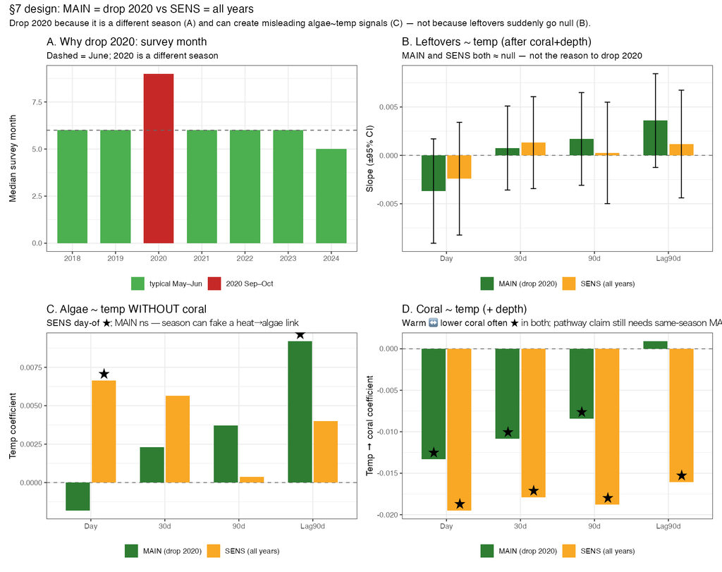

MAIN vs SENS: why drop 2020 (season + artifact), not because leftovers go null

Also see **§7.2** figure (red points = 2020) for how 2020 pulls year-flip correlations.

### Temp ladder map (what each subsection asks)

| Step | Subsection | Question | Model family |
| --- | --- | --- | --- |
| **1** | **§7.1** | After coral+depth, do **leftovers** track heat? | Two-step: by-year `lmer` → residual; then pooled `lm` residual ~ temp + year |
| **2** | **§7.2** | Do §4 β **flips** track survey month / year-mean temp? | Correlate year-level βs with month/temp (MAIN excludes 2020) |
| **3** | **§7.3** | In a **pooled** algae model, is temp still ★? | `lmer` algae ~ … + temp + (1\|Lagoon) + (1\|year) |
| **4** | **§7.4** | Warm → less coral → more algae room? | Coral ~ temp; algae ~ temp with/without coral |
| **5** | **§7.5** | Does **prior-year** heat show up? | Same as above using lag-90d window |
| **6** | **§7.6** | Herb ~ temp? | Exploratory only — no clean theory |

### Models used in §7.1 (leftovers) — put here so §7.1 can stay results-focused

```
Step A — by survey year (build leftovers):
  algae_std ~ coral_std + depth_m_mean + (1 | Lagoon)
  → resid_coral_depth = residual algae after coral + depth

Step B — pooled (MAIN = years ≠ 2020; SENS = all years):
  resid_coral_depth ~ temp_metric + year_f     # ordinary lm + year FE
```

`temp_metric` ∈ {day of sample, 30d before, 90d before, prior-year 90d}.  
Island-wide BTM → little within-year spatial contrast; signal is mostly **timing / year**.

**What each temp window means:**

| Window | Intended ecological meaning | Caveat here |
| --- | --- | --- |
| **Day of sample** | Temp when photographed | Cover does not respond to one day; mostly **survey date** |
| **30d before** | Recent weeks of conditions | Still island-wide |
| **90d before** | Seasonal heat load before survey | Best concurrent “this season” window; still tangled with *when* you surveyed |
| **Prior-year 90d** | Lagged mortality / recovery | Thinner sample; exploratory |

### 7.0 Join coverage (all years shown; 2020 flagged)

Analysis sample + temps (2020 flagged as different season)

| year | n_grids | pct_dated | median_sample_date | median_month | mean_temp_day | mean_temp_30d | mean_temp_90d | season_note |
| --- | --- | --- | --- | --- | --- | --- | --- | --- |
| 2018 | 2964 | 100.0 | 2018-06-30 | 6 | 27.40 | 27.69 | 28.26 | typical May–Jun window |
| 2019 | 1623 | 100.0 | 2019-06-11 | 6 | 28.29 | 28.53 | 29.20 | typical May–Jun window |
| 2020 | 2454 | 100.0 | 2020-09-22 | 9 | 27.01 | 26.86 | 27.06 | DIFFERENT SEASON (Sep–Oct) |
| 2021 | 2081 | 100.0 | 2021-06-22 | 6 | 27.93 | 28.18 | 28.59 | typical May–Jun window |
| 2022 | 1250 | 100.0 | 2022-06-17 | 6 | 27.54 | 27.90 | 28.37 | typical May–Jun window |
| 2023 | 3517 | 100.0 | 2023-06-07 | 6 | 27.73 | 28.21 | 28.62 | typical May–Jun window |
| 2024 | 2030 | 98.7 | 2024-05-28 | 5 | 28.05 | 28.44 | 29.15 | typical May–Jun window |

**2024 dating note**

**27 / 2030** analysis grids (all **Tiaia**) lack `sample_date` in 2024 (~98.7% dated). Those grids still have CoralNet photo counts, but none of their photos joined to a usable `Time` in `photo_metadata_with_gps` (Filename/time parse or year filter). Small localized metadata gap — expected at ~1% rates; they drop out of temp joins only, not from the by-year spatial models in §§1–5.

### 7.1 Partition leftovers — MAIN = drop 2020

**Q:** After coral + depth, does leftover algae track heat?  
**Models:** Steps A–B above (this is ladder step **1**, not “the whole of §7”).

MAIN (drop 2020): pooled leftover algae ~ temp (+ year FE)

| sample | temp_metric | n | n_years | slope | se | t | p | model |
| --- | --- | --- | --- | --- | --- | --- | --- | --- |
| drop_2020_MAIN | Day of sample | 13438 | 6 | -0.0037 | 0.0028 | -1.34 | 0.180 | resid ~ temp + year_FE |
| drop_2020_MAIN | 30d before | 13438 | 6 | 0.0008 | 0.0022 | 0.34 | 0.732 | resid ~ temp + year_FE |
| drop_2020_MAIN | 90d before | 13438 | 6 | 0.0017 | 0.0024 | 0.69 | 0.487 | resid ~ temp + year_FE |
| drop_2020_MAIN | Prior-year 90d (lag) | 10474 | 5 | 0.0036 | 0.0025 | 1.45 | 0.146 | resid ~ temp + year_FE |

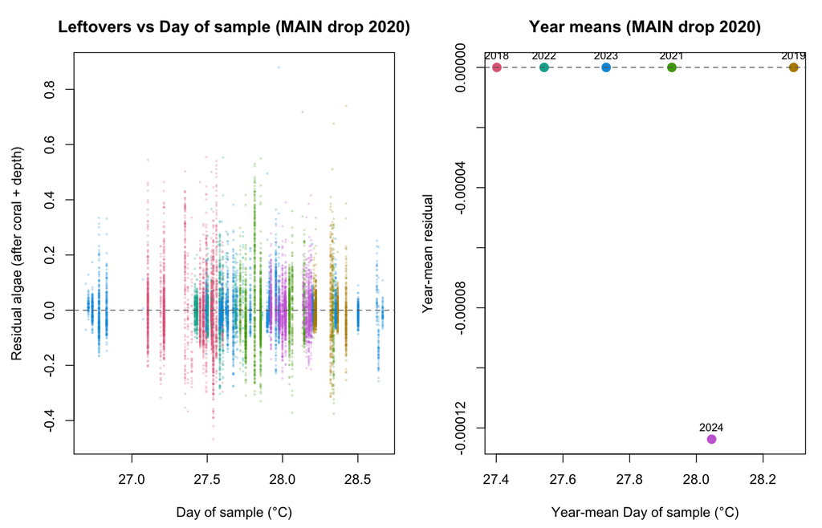

MAIN: leftover algae vs day-of-sample temp